# Preliminaries

```python
# Load libraries

import pandas as pd
from matplotlib import pyplot as plt
import numpy as np
from scipy import stats as st
```

```python
# Load data

df_games = pd.read_csv('/datasets/games.csv')
```

The purpose of this project is to examine data on game sales and identify patterns that will help advertisers improve future sales. I will prepare the data by looking for missing values and other problems before formatting it for analysis. I will explore how game characteristics (e.g., platform, genre, rating, and reviews) impact global and regional sales. Finally, I will conduct statistical tests addressing key questions about specific platforms and genres.

# Examine the Data

```python
# Examine the df_games dataframe

display(df_games.info())
df_games
```

```
<class 'pandas.core.frame.DataFrame'>
RangeIndex: 16715 entries, 0 to 16714
Data columns (total 11 columns):
 #   Column           Non-Null Count  Dtype
---  ------           --------------  -----
 0   Name             16713 non-null  object
 1   Platform         16715 non-null  object
 2   Year_of_Release  16446 non-null  float64
 3   Genre            16713 non-null  object
 4   NA_sales         16715 non-null  float64
 5   EU_sales         16715 non-null  float64
 6   JP_sales         16715 non-null  float64
 7   Other_sales      16715 non-null  float64
 8   Critic_Score     8137 non-null   float64
 9   User_Score       10014 non-null  object
 10  Rating           9949 non-null   object
dtypes: float64(6), object(5)
memory usage: 1.4+ MB
```

```
None
```

|  | Name | Platform | Year_of_Release | Genre | NA_sales | EU_sales | JP_sales | Other_sales | Critic_Score | User_Score | Rating |
| --- | --- | --- | --- | --- | --- | --- | --- | --- | --- | --- | --- |
| 0 | Wii Sports | Wii | 2006.0 | Sports | 41.36 | 28.96 | 3.77 | 8.45 | 76.0 | 8 | E |
| 1 | Super Mario Bros. | NES | 1985.0 | Platform | 29.08 | 3.58 | 6.81 | 0.77 | NaN | NaN | NaN |
| 2 | Mario Kart Wii | Wii | 2008.0 | Racing | 15.68 | 12.76 | 3.79 | 3.29 | 82.0 | 8.3 | E |
| 3 | Wii Sports Resort | Wii | 2009.0 | Sports | 15.61 | 10.93 | 3.28 | 2.95 | 80.0 | 8 | E |
| 4 | Pokemon Red/Pokemon Blue | GB | 1996.0 | Role-Playing | 11.27 | 8.89 | 10.22 | 1.00 | NaN | NaN | NaN |
| ... | ... | ... | ... | ... | ... | ... | ... | ... | ... | ... | ... |
| 16710 | Samurai Warriors: Sanada Maru | PS3 | 2016.0 | Action | 0.00 | 0.00 | 0.01 | 0.00 | NaN | NaN | NaN |
| 16711 | LMA Manager 2007 | X360 | 2006.0 | Sports | 0.00 | 0.01 | 0.00 | 0.00 | NaN | NaN | NaN |
| 16712 | Haitaka no Psychedelica | PSV | 2016.0 | Adventure | 0.00 | 0.00 | 0.01 | 0.00 | NaN | NaN | NaN |
| 16713 | Spirits & Spells | GBA | 2003.0 | Platform | 0.01 | 0.00 | 0.00 | 0.00 | NaN | NaN | NaN |
| 16714 | Winning Post 8 2016 | PSV | 2016.0 | Simulation | 0.00 | 0.00 | 0.01 | 0.00 | NaN | NaN | NaN |

16715 rows × 11 columns

```python
# Change column names to lowercase

df_games.columns = df_games.columns.str.lower()
df_games.info()
```

```
<class 'pandas.core.frame.DataFrame'>
RangeIndex: 16715 entries, 0 to 16714
Data columns (total 11 columns):
 #   Column           Non-Null Count  Dtype
---  ------           --------------  -----
 0   name             16713 non-null  object
 1   platform         16715 non-null  object
 2   year_of_release  16446 non-null  float64
 3   genre            16713 non-null  object
 4   na_sales         16715 non-null  float64
 5   eu_sales         16715 non-null  float64
 6   jp_sales         16715 non-null  float64
 7   other_sales      16715 non-null  float64
 8   critic_score     8137 non-null   float64
 9   user_score       10014 non-null  object
 10  rating           9949 non-null   object
dtypes: float64(6), object(5)
memory usage: 1.4+ MB
```

```python
# Create a function to examine columns

def examine(df, col):
    display(df[col].describe())
    print()
    display(df[col].value_counts())
```

```python
# Examine the name column

examine(df_games, 'name')
```

```
count                           16713
unique                          11559
top       Need for Speed: Most Wanted
freq                               12
Name: name, dtype: object
```

```
Need for Speed: Most Wanted                12
Madden NFL 07                               9
FIFA 14                                     9
Ratatouille                                 9
LEGO Marvel Super Heroes                    9
                                           ..
Dies Irae: Amantes Amentes                  1
Ratchet & Clank Future: Quest for Booty     1
Hunter: The Reckoning Redeemer              1
Jampack Volume 14 (RP-T)                    1
Hoshigami: Ruining Blue Earth               1
Name: name, Length: 11559, dtype: int64
```

```python
# Follow up on the most frequent game to understand the dataset

df_games[df_games['name'] == "Need for Speed: Most Wanted"]
```

|  | name | platform | year_of_release | genre | na_sales | eu_sales | jp_sales | other_sales | critic_score | user_score | rating |
| --- | --- | --- | --- | --- | --- | --- | --- | --- | --- | --- | --- |
| 253 | Need for Speed: Most Wanted | PS2 | 2005.0 | Racing | 2.03 | 1.79 | 0.08 | 0.47 | 82.0 | 9.1 | T |
| 523 | Need for Speed: Most Wanted | PS3 | 2012.0 | Racing | 0.71 | 1.46 | 0.06 | 0.58 | NaN | NaN | NaN |
| 1190 | Need for Speed: Most Wanted | X360 | 2012.0 | Racing | 0.62 | 0.78 | 0.01 | 0.15 | 83.0 | 8.5 | T |
| 1591 | Need for Speed: Most Wanted | X360 | 2005.0 | Racing | 1.00 | 0.13 | 0.02 | 0.10 | 83.0 | 8.5 | T |
| 1998 | Need for Speed: Most Wanted | XB | 2005.0 | Racing | 0.53 | 0.46 | 0.00 | 0.05 | 83.0 | 8.8 | T |
| 2048 | Need for Speed: Most Wanted | PSV | 2012.0 | Racing | 0.33 | 0.45 | 0.01 | 0.22 | NaN | NaN | NaN |
| 3581 | Need for Speed: Most Wanted | GC | 2005.0 | Racing | 0.43 | 0.11 | 0.00 | 0.02 | 80.0 | 9.1 | T |
| 5972 | Need for Speed: Most Wanted | PC | 2005.0 | Racing | 0.02 | 0.23 | 0.00 | 0.04 | 82.0 | 8.5 | T |
| 6273 | Need for Speed: Most Wanted | WiiU | 2013.0 | Racing | 0.13 | 0.12 | 0.00 | 0.02 | NaN | NaN | NaN |
| 6410 | Need for Speed: Most Wanted | DS | 2005.0 | Racing | 0.24 | 0.01 | 0.00 | 0.02 | 45.0 | 6.1 | E |
| 6473 | Need for Speed: Most Wanted | GBA | 2005.0 | Racing | 0.19 | 0.07 | 0.00 | 0.00 | NaN | 8.3 | E |
| 11715 | Need for Speed: Most Wanted | PC | 2012.0 | Racing | 0.00 | 0.06 | 0.00 | 0.02 | 82.0 | 8.5 | T |

```python
# Examine the platform column

examine(df_games, 'platform')
```

```
count     16715
unique       31
top         PS2
freq       2161
Name: platform, dtype: object
```

```
PS2     2161
DS      2151
PS3     1331
Wii     1320
X360    1262
PSP     1209
PS      1197
PC       974
XB       824
GBA      822
GC       556
3DS      520
PSV      430
PS4      392
N64      319
XOne     247
SNES     239
SAT      173
WiiU     147
2600     133
NES       98
GB        98
DC        52
GEN       29
NG        12
WS         6
SCD        6
3DO        3
TG16       2
GG         1
PCFX       1
Name: platform, dtype: int64
```

```python
# Examine the year_of_release column

examine(df_games, 'year_of_release')
```

```
count    16446.000000
mean      2006.484616
std          5.877050
min       1980.000000
25%       2003.000000
50%       2007.000000
75%       2010.000000
max       2016.000000
Name: year_of_release, dtype: float64
```

```
2008.0    1427
2009.0    1426
2010.0    1255
2007.0    1197
2011.0    1136
2006.0    1006
2005.0     939
2002.0     829
2003.0     775
2004.0     762
2012.0     653
2015.0     606
2014.0     581
2013.0     544
2016.0     502
2001.0     482
1998.0     379
2000.0     350
1999.0     338
1997.0     289
1996.0     263
1995.0     219
1994.0     121
1993.0      62
1981.0      46
1992.0      43
1991.0      41
1982.0      36
1986.0      21
1989.0      17
1983.0      17
1987.0      16
1990.0      16
1988.0      15
1984.0      14
1985.0      14
1980.0       9
Name: year_of_release, dtype: int64
```

```python
# Examine the genre column

examine(df_games, 'genre')
```

```
count      16713
unique        12
top       Action
freq        3369
Name: genre, dtype: object
```

```
Action          3369
Sports          2348
Misc            1750
Role-Playing    1498
Shooter         1323
Adventure       1303
Racing          1249
Platform         888
Simulation       873
Fighting         849
Strategy         683
Puzzle           580
Name: genre, dtype: int64
```

```python
# Examine the na_sales column

examine(df_games, 'na_sales')
```

```
count    16715.000000
mean         0.263377
std          0.813604
min          0.000000
25%          0.000000
50%          0.080000
75%          0.240000
max         41.360000
Name: na_sales, dtype: float64
```

```
0.00    4508
0.02     576
0.03     561
0.04     549
0.01     545
        ...
4.12       1
8.41       1
1.97       1
3.70       1
3.43       1
Name: na_sales, Length: 402, dtype: int64
```

```python
# Examine the eu_sales column

examine(df_games, 'eu_sales')
```

```
count    16715.000000
mean         0.145060
std          0.503339
min          0.000000
25%          0.000000
50%          0.020000
75%          0.110000
max         28.960000
Name: eu_sales, dtype: float64
```

```
0.00    5870
0.01    1494
0.02    1308
0.03     926
0.04     709
        ...
9.14       1
1.92       1
3.86       1
2.59       1
3.87       1
Name: eu_sales, Length: 307, dtype: int64
```

```python
# Examine the jp_sales column

examine(df_games, 'jp_sales')
```

```
count    16715.000000
mean         0.077617
std          0.308853
min          0.000000
25%          0.000000
50%          0.000000
75%          0.040000
max         10.220000
Name: jp_sales, dtype: float64
```

```
0.00    10514
0.02      741
0.01      706
0.03      546
0.04      397
        ...
3.84        1
1.17        1
3.03        1
2.66        1
1.71        1
Name: jp_sales, Length: 244, dtype: int64
```

```python
# Examine the other_sales column

examine(df_games, 'other_sales')
```

```
count    16715.000000
mean         0.047342
std          0.186731
min          0.000000
25%          0.000000
50%          0.010000
75%          0.030000
max         10.570000
Name: other_sales, dtype: float64
```

```
0.00    6601
0.01    3464
0.02    1618
0.03     926
0.04     654
        ...
0.72       1
2.11       1
0.96       1
1.48       1
3.96       1
Name: other_sales, Length: 155, dtype: int64
```

```python
# Examine the critic_score column

examine(df_games, 'critic_score')
```

```
count    8137.000000
mean       68.967679
std        13.938165
min        13.000000
25%        60.000000
50%        71.000000
75%        79.000000
max        98.000000
Name: critic_score, dtype: float64
```

```
70.0    256
71.0    254
75.0    245
78.0    240
73.0    238
       ...
29.0      3
13.0      1
22.0      1
17.0      1
21.0      1
Name: critic_score, Length: 82, dtype: int64
```

```python
# Examine the user_score column

examine(df_games, 'user_score')
```

```
count     10014
unique       96
top         tbd
freq       2424
Name: user_score, dtype: object
```

```
tbd    2424
7.8     324
8       290
8.2     282
8.3     254
       ...
1.3       2
0.5       2
0.9       2
9.7       1
0         1
Name: user_score, Length: 96, dtype: int64
```

```python
# Examine the rating column

examine(df_games, 'rating')
```

```
count     9949
unique       8
top          E
freq      3990
Name: rating, dtype: object
```

```
E       3990
T       2961
M       1563
E10+    1420
EC         8
RP         3
K-A        3
AO         1
Name: rating, dtype: int64
```

The data look good overall. I already changed the column names to lowercase. Every column has appropriate data and most are properly formatted. I will change year_of_release and critic_score to integer data types and user_score to float when the time comes.

# Examine the Missing Data

```python
# Examine tbd values

for col in df_games.columns:
    tbds = len(df_games[df_games[col].astype(str).str.lower() == 'tbd'])
    print(f'tbd appears in {col} {tbds} times')

df_games[df_games['user_score'] == 'tbd'].sample(20)
```

```
tbd appears in name 0 times
tbd appears in platform 0 times
tbd appears in year_of_release 0 times
tbd appears in genre 0 times
tbd appears in na_sales 0 times
tbd appears in eu_sales 0 times
tbd appears in jp_sales 0 times
tbd appears in other_sales 0 times
tbd appears in critic_score 0 times
tbd appears in user_score 2424 times
tbd appears in rating 0 times
```

|  | name | platform | year_of_release | genre | na_sales | eu_sales | jp_sales | other_sales | critic_score | user_score | rating |
| --- | --- | --- | --- | --- | --- | --- | --- | --- | --- | --- | --- |
| 9163 | Monster House | GC | 2006.0 | Adventure | 0.11 | 0.03 | 0.0 | 0.00 | 60.0 | tbd | E10+ |
| 4138 | Alice in Wonderland | DS | 2010.0 | Adventure | 0.25 | 0.17 | 0.0 | 0.04 | 78.0 | tbd | E10+ |
| 15016 | Petz: Dolphinz Encounter | DS | 2009.0 | Simulation | 0.01 | 0.01 | 0.0 | 0.00 | NaN | tbd | E |
| 15979 | Monster Trux Offroad | Wii | 2007.0 | Racing | 0.01 | 0.00 | 0.0 | 0.00 | NaN | tbd | E |
| 6309 | Wave Rally | PS2 | 2001.0 | Racing | 0.13 | 0.10 | 0.0 | 0.03 | 62.0 | tbd | E |
| 12547 | World Series of Poker 2008: Battle for the Bra... | DS | 2007.0 | Misc | 0.05 | 0.00 | 0.0 | 0.00 | NaN | tbd | T |
| 7229 | Lethal Skies Elite Pilot: Team SW | PS2 | 2001.0 | Simulation | 0.11 | 0.08 | 0.0 | 0.03 | 59.0 | tbd | E |
| 7781 | IHRA Professional Drag Racing 2005 | PS2 | 2004.0 | Racing | 0.09 | 0.07 | 0.0 | 0.02 | NaN | tbd | E |
| 2411 | SingStar '90s | PS2 | 2007.0 | Misc | 0.10 | 0.59 | 0.0 | 0.18 | 73.0 | tbd | T |
| 3689 | Are You Smarter than a 5th Grader? Make the Grade | Wii | 2008.0 | Misc | 0.50 | 0.00 | 0.0 | 0.04 | NaN | tbd | E |
| 7013 | Sherlock Holmes and the Mystery of Osborne House | DS | 2010.0 | Adventure | 0.07 | 0.14 | 0.0 | 0.03 | 48.0 | tbd | E10+ |
| 11838 | Margot's Word Brain | DS | 2008.0 | Puzzle | 0.07 | 0.00 | 0.0 | 0.01 | NaN | tbd | E10+ |
| 4870 | Planet 51 | DS | 2009.0 | Action | 0.22 | 0.14 | 0.0 | 0.04 | NaN | tbd | E |
| 3947 | Tiger Woods PGA Tour 07 | PS3 | 2006.0 | Sports | 0.31 | 0.12 | 0.0 | 0.07 | 81.0 | tbd | E |
| 2971 | World of Zoo | DS | 2009.0 | Simulation | 0.42 | 0.20 | 0.0 | 0.06 | NaN | tbd | E |
| 15791 | Mechanic Master 2 | DS | 2010.0 | Puzzle | 0.02 | 0.00 | 0.0 | 0.00 | NaN | tbd | E |
| 13267 | Cartoon Network Racing | DS | 2006.0 | Action | 0.04 | 0.00 | 0.0 | 0.00 | 55.0 | tbd | E |
| 8720 | MotionSports: Adrenaline | PS3 | 2011.0 | Sports | 0.08 | 0.05 | 0.0 | 0.02 | NaN | tbd | E |
| 13249 | Super Bust-A-Move | GBA | 2001.0 | Puzzle | 0.03 | 0.01 | 0.0 | 0.00 | 77.0 | tbd | E |
| 11142 | Rock Band Country Track Pack 2 | Wii | 2011.0 | Misc | 0.08 | 0.00 | 0.0 | 0.01 | NaN | tbd | E10+ |

```python
# Compare non-missing, missing, and tbd data in user_score column

tbds = df_games[df_games['user_score'] == 'tbd']
missing = df_games[df_games['user_score'].isna()]
not_missing_or_tbd = df_games[(~df_games['user_score'].isna()) & (df_games['user_score'] != 'tbd')]

display(pd.DataFrame({'user_score': ['not missing or tbd', 'missing', 'tbd', 'total'],
                      'count': [len(not_missing_or_tbd), len(missing), len(tbds), len(df_games)],
                      'percent': [100*len(not_missing_or_tbd)/len(df_games), 100*len(missing)/len(df_games), 100*len(tbds)/len(df_games), 100]
                    }))
print()

for col in ['year_of_release', 'na_sales', 'eu_sales', 'jp_sales', 'other_sales', 'critic_score']:
    print(f'Descriptives of {col} for values of user_score:')
    descriptives = pd.concat([not_missing_or_tbd[col].describe(), missing[col].describe()], axis=1)
    descriptives = pd.concat([descriptives, tbds[col].describe()], axis=1)
    descriptives.columns = ['not missing or tbd', 'missing', 'tbd']

    display(descriptives)
    print()

for col in ['platform', 'genre', 'rating']:
    tbd_values = tbds[col].value_counts(normalize=True) * 100
    missing_values = missing[col].value_counts(normalize=True) * 100
    not_missing_or_tbd_values = not_missing_or_tbd[col].value_counts(normalize=True) * 100
    values = pd.concat([not_missing_or_tbd_values, missing_values, tbd_values], axis=1)
    values.columns = ['not missing or tbd', 'missing', 'tbd']

    print(f'Percentages for each unique value of {col} for values of user_score:')
    display(values)
    print()
```

|  | user_score | count | percent |
| --- | --- | --- | --- |
| 0 | not missing or tbd | 7590 | 45.408316 |
| 1 | missing | 6701 | 40.089740 |
| 2 | tbd | 2424 | 14.501944 |
| 3 | total | 16715 | 100.000000 |

```
Descriptives of year_of_release for values of user_score:
```

|  | not missing or tbd | missing | tbd |
| --- | --- | --- | --- |
| count | 7463.000000 | 6607.000000 | 2376.000000 |
| mean | 2007.686855 | 2004.779325 | 2007.450337 |
| std | 4.296115 | 7.476214 | 3.484229 |
| min | 1985.000000 | 1980.000000 | 1997.000000 |
| 25% | 2004.000000 | 1999.000000 | 2005.000000 |
| 50% | 2008.000000 | 2007.000000 | 2008.000000 |
| 75% | 2011.000000 | 2010.000000 | 2010.000000 |
| max | 2016.000000 | 2016.000000 | 2016.000000 |

```
Descriptives of na_sales for values of user_score:
```

|  | not missing or tbd | missing | tbd |
| --- | --- | --- | --- |
| count | 7590.000000 | 6701.000000 | 2424.000000 |
| mean | 0.375816 | 0.185698 | 0.126052 |
| std | 0.925928 | 0.800778 | 0.180586 |
| min | 0.000000 | 0.000000 | 0.000000 |
| 25% | 0.050000 | 0.000000 | 0.030000 |
| 50% | 0.140000 | 0.000000 | 0.075000 |
| 75% | 0.370000 | 0.120000 | 0.150000 |
| max | 41.360000 | 29.080000 | 3.450000 |

```
Descriptives of eu_sales for values of user_score:
```

|  | not missing or tbd | missing | tbd |
| --- | --- | --- | --- |
| count | 7590.000000 | 6701.000000 | 2424.000000 |
| mean | 0.224893 | 0.091365 | 0.043519 |
| std | 0.658169 | 0.350750 | 0.111412 |
| min | 0.000000 | 0.000000 | 0.000000 |
| 25% | 0.020000 | 0.000000 | 0.000000 |
| 50% | 0.060000 | 0.000000 | 0.010000 |
| 75% | 0.200000 | 0.050000 | 0.040000 |
| max | 28.960000 | 10.950000 | 2.590000 |

```
Descriptives of jp_sales for values of user_score:
```

|  | not missing or tbd | missing | tbd |
| --- | --- | --- | --- |
| count | 7590.000000 | 6701.000000 | 2424.000000 |
| mean | 0.059092 | 0.125690 | 0.002727 |
| std | 0.273972 | 0.384665 | 0.026136 |
| min | 0.000000 | 0.000000 | 0.000000 |
| 25% | 0.000000 | 0.000000 | 0.000000 |
| 50% | 0.000000 | 0.020000 | 0.000000 |
| 75% | 0.010000 | 0.100000 | 0.000000 |
| max | 6.500000 | 10.220000 | 0.860000 |

```
Descriptives of other_sales for values of user_score:
```

|  | not missing or tbd | missing | tbd |
| --- | --- | --- | --- |
| count | 7590.000000 | 6701.000000 | 2424.000000 |
| mean | 0.079389 | 0.022431 | 0.015862 |
| std | 0.258532 | 0.092623 | 0.039156 |
| min | 0.000000 | 0.000000 | 0.000000 |
| 25% | 0.010000 | 0.000000 | 0.000000 |
| 50% | 0.020000 | 0.000000 | 0.010000 |
| 75% | 0.070000 | 0.010000 | 0.020000 |
| max | 10.570000 | 2.740000 | 1.090000 |

```
Descriptives of critic_score for values of user_score:
```

|  | not missing or tbd | missing | tbd |
| --- | --- | --- | --- |
| count | 7017.000000 | 38.000000 | 1082.000000 |
| mean | 70.249822 | 67.289474 | 60.711645 |
| std | 13.880646 | 14.691251 | 11.193035 |
| min | 13.000000 | 33.000000 | 23.000000 |
| 25% | 62.000000 | 58.000000 | 54.000000 |
| 50% | 72.000000 | 66.000000 | 62.000000 |
| 75% | 80.000000 | 82.000000 | 69.000000 |
| max | 98.000000 | 89.000000 | 90.000000 |

```
Percentages for each unique value of platform for values of user_score:
```

|  | not missing or tbd | missing | tbd |
| --- | --- | --- | --- |
| PS2 | 16.350461 | 10.147739 | 9.900990 |
| X360 | 12.727273 | 3.163707 | 3.465347 |
| PS3 | 11.554677 | 5.476795 | 3.589109 |
| PC | 10.144928 | 2.313088 | 2.021452 |
| XB | 7.720685 | 1.313237 | 6.188119 |
| Wii | 7.378129 | 4.775407 | 18.151815 |
| DS | 6.798419 | 13.117445 | 31.188119 |
| PSP | 5.546772 | 9.923892 | 5.074257 |
| GC | 4.822134 | 1.298314 | 4.249175 |
| PS4 | 3.386034 | 1.925086 | 0.247525 |
| GBA | 3.359684 | 4.551559 | 10.808581 |
| XOne | 2.397892 | 0.805850 | 0.453795 |
| 3DS | 2.292490 | 4.327712 | 2.310231 |
| PS | 2.134387 | 14.773914 | 1.856436 |
| PSV | 1.884058 | 4.178481 | 0.288779 |
| WiiU | 1.317523 | 0.626772 | 0.206271 |
| DC | 0.184453 | 0.567080 | NaN |
| N64 | NaN | 4.760484 | NaN |
| SNES | NaN | 3.566632 | NaN |
| SAT | NaN | 2.581704 | NaN |
| 2600 | NaN | 1.984778 | NaN |
| NES | NaN | 1.462468 | NaN |
| GB | NaN | 1.462468 | NaN |
| GEN | NaN | 0.432771 | NaN |
| NG | NaN | 0.179078 | NaN |
| WS | NaN | 0.089539 | NaN |
| SCD | NaN | 0.089539 | NaN |
| 3DO | NaN | 0.044769 | NaN |
| TG16 | NaN | 0.029846 | NaN |
| PCFX | NaN | 0.014923 | NaN |
| GG | NaN | 0.014923 | NaN |

```
Percentages for each unique value of genre for values of user_score:
```

|  | not missing or tbd | missing | tbd |
| --- | --- | --- | --- |
| Action | 24.110672 | 17.360800 | 15.511551 |
| Sports | 14.532279 | 12.419764 | 17.037954 |
| Shooter | 12.173913 | 4.478280 | 4.084158 |
| Role-Playing | 9.789196 | 10.822511 | 1.237624 |
| Racing | 8.445323 | 5.597850 | 9.612211 |
| Misc | 5.783926 | 12.867592 | 18.523102 |
| Platform | 5.638999 | 4.791760 | 5.734323 |
| Fighting | 5.256917 | 6.135244 | 1.608911 |
| Simulation | 4.532279 | 4.358860 | 9.777228 |
| Strategy | 4.097497 | 4.970891 | 1.608911 |
| Adventure | 3.952569 | 12.598895 | 6.559406 |
| Puzzle | 1.686430 | 3.597552 | 8.704620 |

```
Percentages for each unique value of rating for values of user_score:
```

|  | not missing or tbd | missing | tbd |
| --- | --- | --- | --- |
| T | 34.128465 | 28.169014 | 16.006740 |
| E | 31.649787 | 56.338028 | 66.343724 |
| M | 20.229211 | 4.225352 | 1.769166 |
| E10+ | 13.899254 | 9.859155 | 15.585510 |
| K-A | 0.039979 | NaN | NaN |
| RP | 0.026652 | 1.408451 | NaN |
| EC | 0.013326 | NaN | 0.294861 |
| AO | 0.013326 | NaN | NaN |

Values of "tbd" appear 2,424 times in the user_score column and nowhere else. For the user_score column, 40% of rows are missing and 15% are tbds, but nothing obviously distinguishes them from regular rows (neither tbd nor missing). Tbd rows have comparable year_of_release values, slightly lower critic_scores, and considerably lower sales than regular and missing rows.

For na_sales, eu_sales, and other_sales, values in regular rows are a little more than twice as large as those in missing rows, which are a little less than twice as large as those in tbd rows. The pattern is different for jp_sales where values in missing rows are twice as large as those in regular rows and 46 times as large as those in tbd rows.

Tbd rows are low on PS2, X360, PS3, PC, and PS4 platforms (all Sony or Microsoft) and high on Wii, DS, and GBA (all Nintendo). Whereas tbd rows are low on Shooter, Role-Player, and Fighting genres and T and M ratings, they are high on Misc and Puzzle genres and E ratings.

Tbds seem to be predominantly games made by Nintendo, marketed for kids, and low in violence. Since those categories overlap and the relevant differences are not sharp, I still cannot say which is most important. Tbds also appear to be either unpopular or unreleased in Japan. That offers an interesting profile of tbds, but offers no guidance on what to do with them. I will convert "tbd" to NaN and treat it like other missing data.

```python
# Print out the number and percentage of missing values in each column

display(df_games.info())

df_missing_values = df_games.isna().sum().reset_index()
df_missing_values.columns = ['column', 'missing values']
df_missing_values['percent missing'] = 100*df_missing_values['missing values']/len(df_games)

display(round(df_missing_values, 2))
```

```
<class 'pandas.core.frame.DataFrame'>
RangeIndex: 16715 entries, 0 to 16714
Data columns (total 11 columns):
 #   Column           Non-Null Count  Dtype
---  ------           --------------  -----
 0   name             16713 non-null  object
 1   platform         16715 non-null  object
 2   year_of_release  16446 non-null  float64
 3   genre            16713 non-null  object
 4   na_sales         16715 non-null  float64
 5   eu_sales         16715 non-null  float64
 6   jp_sales         16715 non-null  float64
 7   other_sales      16715 non-null  float64
 8   critic_score     8137 non-null   float64
 9   user_score       10014 non-null  object
 10  rating           9949 non-null   object
dtypes: float64(6), object(5)
memory usage: 1.4+ MB
```

```
None
```

|  | column | missing values | percent missing |
| --- | --- | --- | --- |
| 0 | name | 2 | 0.01 |
| 1 | platform | 0 | 0.00 |
| 2 | year_of_release | 269 | 1.61 |
| 3 | genre | 2 | 0.01 |
| 4 | na_sales | 0 | 0.00 |
| 5 | eu_sales | 0 | 0.00 |
| 6 | jp_sales | 0 | 0.00 |
| 7 | other_sales | 0 | 0.00 |
| 8 | critic_score | 8578 | 51.32 |
| 9 | user_score | 6701 | 40.09 |
| 10 | rating | 6766 | 40.48 |

```python
# Examine missing data in name, genre, and year_of_release columns

display(df_games[df_games['name'].isna()])
display(df_games[df_games['genre'].isna()])
df_games[df_games['year_of_release'].isna()].sample(20)
```

|  | name | platform | year_of_release | genre | na_sales | eu_sales | jp_sales | other_sales | critic_score | user_score | rating |
| --- | --- | --- | --- | --- | --- | --- | --- | --- | --- | --- | --- |
| 659 | NaN | GEN | 1993.0 | NaN | 1.78 | 0.53 | 0.00 | 0.08 | NaN | NaN | NaN |
| 14244 | NaN | GEN | 1993.0 | NaN | 0.00 | 0.00 | 0.03 | 0.00 | NaN | NaN | NaN |

|  | name | platform | year_of_release | genre | na_sales | eu_sales | jp_sales | other_sales | critic_score | user_score | rating |
| --- | --- | --- | --- | --- | --- | --- | --- | --- | --- | --- | --- |
| 659 | NaN | GEN | 1993.0 | NaN | 1.78 | 0.53 | 0.00 | 0.08 | NaN | NaN | NaN |
| 14244 | NaN | GEN | 1993.0 | NaN | 0.00 | 0.00 | 0.03 | 0.00 | NaN | NaN | NaN |

|  | name | platform | year_of_release | genre | na_sales | eu_sales | jp_sales | other_sales | critic_score | user_score | rating |
| --- | --- | --- | --- | --- | --- | --- | --- | --- | --- | --- | --- |
| 14325 | Beyond the Labyrinth | 3DS | NaN | Role-Playing | 0.00 | 0.00 | 0.03 | 0.00 | NaN | NaN | NaN |
| 9876 | Major League Baseball 2K6 | PSP | NaN | Sports | 0.11 | 0.00 | 0.00 | 0.01 | 69.0 | tbd | E |
| 7605 | Famista 64 | N64 | NaN | Sports | 0.00 | 0.00 | 0.17 | 0.03 | NaN | NaN | NaN |
| 7735 | Test Drive Unlimited 2 | PC | NaN | Racing | 0.05 | 0.11 | 0.00 | 0.03 | 72.0 | 5.7 | T |
| 11832 | Smashing Drive | GC | NaN | Racing | 0.06 | 0.01 | 0.00 | 0.00 | 47.0 | 5.2 | T |
| 6476 | LEGO Harry Potter: Years 5-7 | PSP | NaN | Action | 0.10 | 0.10 | 0.00 | 0.06 | NaN | tbd | E10+ |
| 9703 | Record of Agarest War Zero | PS3 | NaN | Strategy | 0.09 | 0.00 | 0.03 | 0.01 | 50.0 | 6.7 | T |
| 6624 | College Hoops 2K6 | PS2 | NaN | Sports | 0.12 | 0.10 | 0.00 | 0.03 | 77.0 | 7.3 | E |
| 9485 | Street Fighter IV | PC | NaN | Fighting | 0.07 | 0.05 | 0.00 | 0.02 | 91.0 | 8 | T |
| 8632 | Vegas Party | Wii | NaN | Misc | 0.15 | 0.00 | 0.00 | 0.01 | 33.0 | tbd | T |
| 2536 | Shaun White Snowboarding | X360 | NaN | Sports | 0.48 | 0.25 | 0.00 | 0.08 | 60.0 | 7.6 | T |
| 13289 | Reader Rabbit 2nd Grade | Wii | NaN | Misc | 0.04 | 0.00 | 0.00 | 0.00 | NaN | tbd | E |
| 678 | LEGO Indiana Jones: The Original Adventures | Wii | NaN | Action | 1.51 | 0.61 | 0.00 | 0.21 | 78.0 | 6.6 | E10+ |
| 15006 | Tube Slider | GC | NaN | Racing | 0.02 | 0.00 | 0.00 | 0.00 | 62.0 | tbd | E |
| 2969 | Test Drive Unlimited 2 | X360 | NaN | Racing | 0.30 | 0.31 | 0.00 | 0.07 | 68.0 | 6.4 | T |
| 1650 | NASCAR Thunder 2003 | PS2 | NaN | Racing | 0.60 | 0.46 | 0.00 | 0.16 | 84.0 | 8.7 | E |
| 2849 | Madden NFL 11 | Wii | NaN | Sports | 0.68 | 0.00 | 0.00 | 0.04 | 75.0 | 5.4 | E |
| 2522 | The Lord of the Rings: War in the North | PS3 | NaN | Action | 0.25 | 0.42 | 0.01 | 0.13 | 63.0 | 7 | M |
| 15795 | Shonen Jump's Yu-Gi-Oh! GX Card Almanac | DS | NaN | Misc | 0.00 | 0.00 | 0.02 | 0.00 | NaN | NaN | NaN |
| 15081 | Wii de Asobu: Metroid Prime | Wii | NaN | Shooter | 0.00 | 0.00 | 0.02 | 0.00 | NaN | NaN | NaN |

```python
# Examine missing-value overlap

print(f"missing user_score = {len(df_games[df_games['user_score'].isna()])}")
print(f"user_score is tbd = {len(df_games[df_games['user_score'] == 'tbd'])}")
print(f"missing user_score total = {len(df_games[((df_games['user_score'].isna()) | (df_games['user_score'] == 'tbd'))])}")
print(f"missing critic_score = {len(df_games[df_games['critic_score'].isna()])}")
print(f"missing rating = {len(df_games[df_games['rating'].isna()])}")
print()
print(f"missing user_score and critic_score = {len(df_games[(df_games['user_score'].isna()) & (df_games['critic_score'].isna())])}")
print(f"user_score is tbd and critic_score = {len(df_games[(df_games['user_score'] == 'tbd') & (df_games['critic_score'].isna())])}")
print(f"missing user_score and rating = {len(df_games[(df_games['user_score'].isna()) & (df_games['rating'].isna())])}")
print(f"user_score is tbd and rating = {len(df_games[(df_games['user_score'] == 'tbd') & (df_games['rating'].isna())])}")
print(f"missing critic_score and rating = {len(df_games[(df_games['critic_score'].isna()) & (df_games['rating'].isna())])}")
print()
print(f"missing user_score and critic_score and rating = {len(df_games[(df_games['user_score'].isna()) & (df_games['critic_score'].isna()) & (df_games['rating'].isna())])}")
print(f"user_score is tbd and critic_score and rating = {len(df_games[(df_games['user_score'] == 'tbd') & (df_games['critic_score'].isna()) & (df_games['rating'].isna())])}")
```

```
missing user_score = 6701
user_score is tbd = 2424
missing user_score total = 9125
missing critic_score = 8578
missing rating = 6766

missing user_score and critic_score = 6663
user_score is tbd and critic_score = 1342
missing user_score and rating = 6630
user_score is tbd and rating = 50
missing critic_score and rating = 6683

missing user_score and critic_score and rating = 6621
user_score is tbd and critic_score and rating = 46
```

```python
# Add a column to facilitate exploring the unjudged (rows missing values in critic_score, user_score, and rating columns)

df_games['unjudged'] = (df_games['user_score'].isna() & df_games['critic_score'].isna() & df_games['rating'].isna()).astype(int)

display(df_games['unjudged'].value_counts())
df_games
```

```
0    10094
1     6621
Name: unjudged, dtype: int64
```

|  | name | platform | year_of_release | genre | na_sales | eu_sales | jp_sales | other_sales | critic_score | user_score | rating | unjudged |
| --- | --- | --- | --- | --- | --- | --- | --- | --- | --- | --- | --- | --- |
| 0 | Wii Sports | Wii | 2006.0 | Sports | 41.36 | 28.96 | 3.77 | 8.45 | 76.0 | 8 | E | 0 |
| 1 | Super Mario Bros. | NES | 1985.0 | Platform | 29.08 | 3.58 | 6.81 | 0.77 | NaN | NaN | NaN | 1 |
| 2 | Mario Kart Wii | Wii | 2008.0 | Racing | 15.68 | 12.76 | 3.79 | 3.29 | 82.0 | 8.3 | E | 0 |
| 3 | Wii Sports Resort | Wii | 2009.0 | Sports | 15.61 | 10.93 | 3.28 | 2.95 | 80.0 | 8 | E | 0 |
| 4 | Pokemon Red/Pokemon Blue | GB | 1996.0 | Role-Playing | 11.27 | 8.89 | 10.22 | 1.00 | NaN | NaN | NaN | 1 |
| ... | ... | ... | ... | ... | ... | ... | ... | ... | ... | ... | ... | ... |
| 16710 | Samurai Warriors: Sanada Maru | PS3 | 2016.0 | Action | 0.00 | 0.00 | 0.01 | 0.00 | NaN | NaN | NaN | 1 |
| 16711 | LMA Manager 2007 | X360 | 2006.0 | Sports | 0.00 | 0.01 | 0.00 | 0.00 | NaN | NaN | NaN | 1 |
| 16712 | Haitaka no Psychedelica | PSV | 2016.0 | Adventure | 0.00 | 0.00 | 0.01 | 0.00 | NaN | NaN | NaN | 1 |
| 16713 | Spirits & Spells | GBA | 2003.0 | Platform | 0.01 | 0.00 | 0.00 | 0.00 | NaN | NaN | NaN | 1 |
| 16714 | Winning Post 8 2016 | PSV | 2016.0 | Simulation | 0.00 | 0.00 | 0.01 | 0.00 | NaN | NaN | NaN | 1 |

16715 rows × 12 columns

```python
# Examine rows missing values in the critic_score column but not unjudged

df_games[(df_games['critic_score'].isna()) & ((~df_games['unjudged']))].sample(20)
```

|  | name | platform | year_of_release | genre | na_sales | eu_sales | jp_sales | other_sales | critic_score | user_score | rating | unjudged |
| --- | --- | --- | --- | --- | --- | --- | --- | --- | --- | --- | --- | --- |
| 15891 | Rugby League Live 3 | PS3 | 2015.0 | Action | 0.00 | 0.01 | 0.00 | 0.00 | NaN | tbd | NaN | 0 |
| 6046 | Sesame Street: Cookie's Counting Carnival | Wii | 2010.0 | Misc | 0.27 | 0.00 | 0.00 | 0.02 | NaN | tbd | EC | 0 |
| 2020 | ZhuZhu Pets | DS | 2010.0 | Simulation | 0.67 | 0.26 | 0.00 | 0.09 | NaN | tbd | E | 0 |
| 11439 | Transformers: Devastation | X360 | 2015.0 | Action | 0.06 | 0.01 | 0.00 | 0.01 | NaN | 8.4 | T | 0 |
| 4252 | LEGO The Hobbit | PS3 | 2014.0 | Action | 0.12 | 0.27 | 0.00 | 0.07 | NaN | 7 | E10+ | 0 |
| 12856 | Ski Region Simulator | PC | 2011.0 | Simulation | 0.00 | 0.05 | 0.00 | 0.01 | NaN | tbd | NaN | 0 |
| 7560 | Jillian Michaels' Fitness Adventure | X360 | 2011.0 | Misc | 0.17 | 0.02 | 0.00 | 0.01 | NaN | tbd | E | 0 |
| 6184 | Corvette | GBA | 2003.0 | Racing | 0.20 | 0.07 | 0.00 | 0.01 | NaN | tbd | E | 0 |
| 10407 | Big League Sports: Summer | DS | 2009.0 | Sports | 0.09 | 0.00 | 0.00 | 0.01 | NaN | tbd | E | 0 |
| 9329 | Pinball Hall of Fame: The Gottlieb Collection | Wii | 2006.0 | Misc | 0.12 | 0.00 | 0.00 | 0.01 | NaN | tbd | E | 0 |
| 3520 | Rapala: We Fish | Wii | 2009.0 | Sports | 0.52 | 0.01 | 0.00 | 0.04 | NaN | tbd | E | 0 |
| 1586 | Watch Dogs | X360 | 2014.0 | Action | 0.72 | 0.41 | 0.01 | 0.11 | NaN | 5 | M | 0 |
| 3484 | Pro Evolution Soccer 2015 | PS3 | 2014.0 | Sports | 0.10 | 0.20 | 0.22 | 0.06 | NaN | 7.8 | E | 0 |
| 11553 | Pony Friends 2 | Wii | 2009.0 | Simulation | 0.03 | 0.04 | 0.00 | 0.01 | NaN | tbd | E | 0 |
| 7587 | Rock Band Track Pack: Classic Rock | PS2 | 2009.0 | Misc | 0.10 | 0.08 | 0.00 | 0.03 | NaN | tbd | T | 0 |
| 11835 | America's Next Top Model | Wii | 2010.0 | Action | 0.07 | 0.00 | 0.00 | 0.00 | NaN | tbd | E10+ | 0 |
| 5272 | AMF Bowling World Lanes | Wii | 2008.0 | Sports | 0.33 | 0.00 | 0.00 | 0.03 | NaN | 1.1 | E | 0 |
| 2589 | EA Sports Active NFL Training Camp | Wii | 2010.0 | Sports | 0.75 | 0.00 | 0.00 | 0.05 | NaN | tbd | E | 0 |
| 12255 | Interactive Storybook DS Series 1 | DS | 2007.0 | Misc | 0.06 | 0.00 | 0.00 | 0.00 | NaN | tbd | E | 0 |
| 11114 | Monster Jam: Path of Destruction | PSP | 2010.0 | Racing | 0.08 | 0.00 | 0.00 | 0.01 | NaN | tbd | E | 0 |

Thousands of values are missing in the critic_score, user_score, and rating columns, 269 are missing in the year_of_release column, and 2 rows are missing values in both the name and genre columns. The two rows without name and genre are also missing score and rating data but they do contain sales data, so I will keep them for that purpose. I do not see any obvious patterns to explain the missing values in year_of_release, so I will assume they are random.

```python
# Compare unjudged rows to the rest

unjudged = df_games[df_games['unjudged'] == 1]
judged = df_games[df_games['unjudged'] == 0]
unjudged = unjudged[unjudged['user_score'] != 'tbd']
judged = judged[judged['user_score'] != 'tbd']

for col in ['year_of_release', 'na_sales', 'eu_sales', 'jp_sales', 'other_sales']:
    unjudged_col = unjudged[col].astype(float)
    judged_col = judged[col].astype(float)
    descriptives = pd.concat([judged_col.describe(), unjudged_col.describe()], axis=1)
    descriptives.columns = [f'judged', f'unjudged']
    test = st.ttest_ind(unjudged_col, judged_col, equal_var=False, nan_policy='omit')

    print(col)
    display(descriptives[:3].T)
    print()

for col in ['platform', 'genre']:
    unjudged_values = unjudged[col].value_counts(normalize=True) * 100
    judged_values = judged[col].value_counts(normalize=True) * 100
    values = pd.concat([judged_values, unjudged_values], axis=1).dropna()
    values.columns = ['judged', 'unjudged']
    values['ratio (j/u)'] = values['judged'] / values['unjudged']
    values['ratio (u/j)'] = 1 / values['ratio (j/u)']

    print(f'{col}:')
    display(values)
    print()
```

```
year_of_release
```

|  | count | mean | std |
| --- | --- | --- | --- |
| judged | 7534.0 | 2007.689010 | 4.307082 |
| unjudged | 6536.0 | 2004.745257 | 7.488945 |

```
na_sales
```

|  | count | mean | std |
| --- | --- | --- | --- |
| judged | 7670.0 | 0.373133 | 0.922325 |
| unjudged | 6621.0 | 0.186508 | 0.804416 |

```
eu_sales
```

|  | count | mean | std |
| --- | --- | --- | --- |
| judged | 7670.0 | 0.223630 | 0.655679 |
| unjudged | 6621.0 | 0.091216 | 0.351058 |

```
jp_sales
```

|  | count | mean | std |
| --- | --- | --- | --- |
| judged | 7670.0 | 0.058876 | 0.272851 |
| unjudged | 6621.0 | 0.126745 | 0.386614 |

```
other_sales
```

|  | count | mean | std |
| --- | --- | --- | --- |
| judged | 7670.0 | 0.078717 | 0.257309 |
| unjudged | 6621.0 | 0.022521 | 0.093033 |

```
platform:
```

|  | judged | unjudged | ratio (j/u) | ratio (u/j) |
| --- | --- | --- | --- | --- |
| PS2 | 16.205997 | 10.240145 | 1.582595 | 0.631874 |
| X360 | 12.737940 | 3.035795 | 4.195915 | 0.238327 |
| PS3 | 11.486310 | 5.482556 | 2.095065 | 0.477312 |
| PC | 10.208605 | 2.144691 | 4.759942 | 0.210087 |
| XB | 7.653194 | 1.314001 | 5.824345 | 0.171693 |
| Wii | 7.392438 | 4.727383 | 1.563749 | 0.639489 |
| DS | 6.975228 | 12.988974 | 0.537011 | 1.862158 |
| PSP | 5.514993 | 10.013593 | 0.550751 | 1.815704 |
| GC | 4.771838 | 1.314001 | 3.631534 | 0.275366 |
| PS4 | 3.402868 | 1.887932 | 1.802431 | 0.554806 |
| GBA | 3.389831 | 4.531038 | 0.748136 | 1.336656 |
| XOne | 2.385919 | 0.800483 | 2.980598 | 0.335503 |
| 3DS | 2.294654 | 4.349796 | 0.527532 | 1.895621 |
| PS | 2.203390 | 14.846700 | 0.148409 | 6.738118 |
| PSV | 1.890482 | 4.198762 | 0.450248 | 2.221000 |
| WiiU | 1.303781 | 0.634345 | 2.055318 | 0.486543 |
| DC | 0.182529 | 0.573931 | 0.318033 | 3.144324 |

```
genre:
```

|  | judged | unjudged | ratio (j/u) | ratio (u/j) |
| --- | --- | --- | --- | --- |
| Action | 24.015645 | 17.389334 | 1.381056 | 0.724084 |
| Sports | 14.524120 | 12.403686 | 1.170952 | 0.854006 |
| Shooter | 12.073012 | 4.502191 | 2.681586 | 0.372914 |
| Role-Playing | 9.778357 | 10.847560 | 0.901434 | 1.109344 |
| Racing | 8.500652 | 5.499320 | 1.545764 | 0.646929 |
| Misc | 5.801825 | 12.932467 | 0.448625 | 2.229034 |
| Platform | 5.606258 | 4.819459 | 1.163255 | 0.859657 |
| Fighting | 5.228162 | 6.179181 | 0.846093 | 1.181903 |
| Simulation | 4.537158 | 4.351110 | 1.042759 | 0.958995 |
| Strategy | 4.080834 | 5.000755 | 0.816044 | 1.225425 |
| Adventure | 4.080834 | 12.554767 | 0.325043 | 3.076519 |
| Puzzle | 1.773142 | 3.520169 | 0.503709 | 1.985272 |

Compared to the others, unjudged rows have slightly lower values in year_of_release and values twice as high in jp_sales but less than half as high in the other three sales columns (na_sales, eu_sales, and other_sales). PS, DC, and PSV consoles and Adventure and Misc genres are at least twice as common in unjudged rows as in the rest, and XB, PC, X360, GC, XOne, and WiiU consoles and the Shooter genre are less than half as common. I fail to see any helpful patterns except that games in the unjudged rows sell well in Japan and nowhere else.

Between the tbds and unjudged, something is going on with Japan in this dataset, but I still have not put it together. The critic_score, user_score, and rating data probably all came from a separate smaller dataset, hence the overlapping missing values. There might well be a reason the smaller dataset is missing 40% of the games in the full dataset. Maybe the missing games were primarily sold in Japan or to Japanese speakers and not covered by the US-based website aggregating scores and ratings. I have no way to confirm that with these data and it also has no bearing on how I should treat the missing values.

I prefer to retain as much data as possible by deleting missing values pairwise only when necessary, so I will not delete any rows. I also prefer to avoid fabricating data by routinely imputing missing values. If a row is missing the critic score, for example, I have no reason to believe much less assert that it should be the column mean. I will leave the missing data as it is but I will convert year_of_release and critic_score columns to a nullable integer data type for easier processing. I will also replace "tbd" values in user_score with NaNs and change that column to a float data type. Finally, I will delete the superfluous unjudged column.

# Prepare the Data

```python
# Change tbds in user_score column to NaNs

df_games['user_score'] = df_games['user_score'].replace('tbd', np.nan)

tbds = len(df_games[df_games['user_score'] == 'tbd'])
print(f'tbd appears in {col} {tbds} times')
```

```
tbd appears in genre 0 times
```

```python
# Change user_score column to float data type

df_games['user_score'] = df_games['user_score'].astype(float)

df_games.info()
```

```
<class 'pandas.core.frame.DataFrame'>
RangeIndex: 16715 entries, 0 to 16714
Data columns (total 12 columns):
 #   Column           Non-Null Count  Dtype
---  ------           --------------  -----
 0   name             16713 non-null  object
 1   platform         16715 non-null  object
 2   year_of_release  16446 non-null  float64
 3   genre            16713 non-null  object
 4   na_sales         16715 non-null  float64
 5   eu_sales         16715 non-null  float64
 6   jp_sales         16715 non-null  float64
 7   other_sales      16715 non-null  float64
 8   critic_score     8137 non-null   float64
 9   user_score       7590 non-null   float64
 10  rating           9949 non-null   object
 11  unjudged         16715 non-null  int64
dtypes: float64(7), int64(1), object(4)
memory usage: 1.5+ MB
```

```python
# Check before converting float columns to Int64

def check_float_for_int(df, column):
    mask = df[column].notna()
    are_integers = np.all(np.floor(df[column][mask]) == df[column][mask])

    if are_integers:
        print(f"All non-missing values in the {column} column are integers: proceed to convert")
    else:
        print(f"Some non-missing values in the {column} column are not integers: DO NOT convert")

check_float_for_int(df_games, 'year_of_release')
check_float_for_int(df_games, 'critic_score')
check_float_for_int(df_games, 'user_score')
```

```
All non-missing values in the year_of_release column are integers: proceed to convert
All non-missing values in the critic_score column are integers: proceed to convert
Some non-missing values in the user_score column are not integers: DO NOT convert
```

```python
# Convert float columns to Int64

df_games['year_of_release'] = df_games['year_of_release'].astype('Int64')
df_games['critic_score'] = df_games['critic_score'].astype('Int64')

display(df_games.info())
df_games
```

```
<class 'pandas.core.frame.DataFrame'>
RangeIndex: 16715 entries, 0 to 16714
Data columns (total 12 columns):
 #   Column           Non-Null Count  Dtype
---  ------           --------------  -----
 0   name             16713 non-null  object
 1   platform         16715 non-null  object
 2   year_of_release  16446 non-null  Int64
 3   genre            16713 non-null  object
 4   na_sales         16715 non-null  float64
 5   eu_sales         16715 non-null  float64
 6   jp_sales         16715 non-null  float64
 7   other_sales      16715 non-null  float64
 8   critic_score     8137 non-null   Int64
 9   user_score       7590 non-null   float64
 10  rating           9949 non-null   object
 11  unjudged         16715 non-null  int64
dtypes: Int64(2), float64(5), int64(1), object(4)
memory usage: 1.6+ MB
```

```
None
```

|  | name | platform | year_of_release | genre | na_sales | eu_sales | jp_sales | other_sales | critic_score | user_score | rating | unjudged |
| --- | --- | --- | --- | --- | --- | --- | --- | --- | --- | --- | --- | --- |
| 0 | Wii Sports | Wii | 2006 | Sports | 41.36 | 28.96 | 3.77 | 8.45 | 76 | 8.0 | E | 0 |
| 1 | Super Mario Bros. | NES | 1985 | Platform | 29.08 | 3.58 | 6.81 | 0.77 | <NA> | NaN | NaN | 1 |
| 2 | Mario Kart Wii | Wii | 2008 | Racing | 15.68 | 12.76 | 3.79 | 3.29 | 82 | 8.3 | E | 0 |
| 3 | Wii Sports Resort | Wii | 2009 | Sports | 15.61 | 10.93 | 3.28 | 2.95 | 80 | 8.0 | E | 0 |
| 4 | Pokemon Red/Pokemon Blue | GB | 1996 | Role-Playing | 11.27 | 8.89 | 10.22 | 1.00 | <NA> | NaN | NaN | 1 |
| ... | ... | ... | ... | ... | ... | ... | ... | ... | ... | ... | ... | ... |
| 16710 | Samurai Warriors: Sanada Maru | PS3 | 2016 | Action | 0.00 | 0.00 | 0.01 | 0.00 | <NA> | NaN | NaN | 1 |
| 16711 | LMA Manager 2007 | X360 | 2006 | Sports | 0.00 | 0.01 | 0.00 | 0.00 | <NA> | NaN | NaN | 1 |
| 16712 | Haitaka no Psychedelica | PSV | 2016 | Adventure | 0.00 | 0.00 | 0.01 | 0.00 | <NA> | NaN | NaN | 1 |
| 16713 | Spirits & Spells | GBA | 2003 | Platform | 0.01 | 0.00 | 0.00 | 0.00 | <NA> | NaN | NaN | 1 |
| 16714 | Winning Post 8 2016 | PSV | 2016 | Simulation | 0.00 | 0.00 | 0.01 | 0.00 | <NA> | NaN | NaN | 1 |

16715 rows × 12 columns

```python
# replace the NaN values in the "rating" column with a placeholder

df_games['rating'].fillna("unknown", inplace=True)

display(df_games)
```

|  | name | platform | year_of_release | genre | na_sales | eu_sales | jp_sales | other_sales | critic_score | user_score | rating | unjudged |
| --- | --- | --- | --- | --- | --- | --- | --- | --- | --- | --- | --- | --- |
| 0 | Wii Sports | Wii | 2006 | Sports | 41.36 | 28.96 | 3.77 | 8.45 | 76 | 8.0 | E | 0 |
| 1 | Super Mario Bros. | NES | 1985 | Platform | 29.08 | 3.58 | 6.81 | 0.77 | <NA> | NaN | unknown | 1 |
| 2 | Mario Kart Wii | Wii | 2008 | Racing | 15.68 | 12.76 | 3.79 | 3.29 | 82 | 8.3 | E | 0 |
| 3 | Wii Sports Resort | Wii | 2009 | Sports | 15.61 | 10.93 | 3.28 | 2.95 | 80 | 8.0 | E | 0 |
| 4 | Pokemon Red/Pokemon Blue | GB | 1996 | Role-Playing | 11.27 | 8.89 | 10.22 | 1.00 | <NA> | NaN | unknown | 1 |
| ... | ... | ... | ... | ... | ... | ... | ... | ... | ... | ... | ... | ... |
| 16710 | Samurai Warriors: Sanada Maru | PS3 | 2016 | Action | 0.00 | 0.00 | 0.01 | 0.00 | <NA> | NaN | unknown | 1 |
| 16711 | LMA Manager 2007 | X360 | 2006 | Sports | 0.00 | 0.01 | 0.00 | 0.00 | <NA> | NaN | unknown | 1 |
| 16712 | Haitaka no Psychedelica | PSV | 2016 | Adventure | 0.00 | 0.00 | 0.01 | 0.00 | <NA> | NaN | unknown | 1 |
| 16713 | Spirits & Spells | GBA | 2003 | Platform | 0.01 | 0.00 | 0.00 | 0.00 | <NA> | NaN | unknown | 1 |
| 16714 | Winning Post 8 2016 | PSV | 2016 | Simulation | 0.00 | 0.00 | 0.01 | 0.00 | <NA> | NaN | unknown | 1 |

16715 rows × 12 columns

```python
# Add a total sales column and delete the unjudged column

df_games['total_sales'] = df_games['na_sales'] + df_games['eu_sales'] + df_games['jp_sales'] + df_games['other_sales']
del df_games['unjudged']

display(df_games.info())
df_games
```

```
<class 'pandas.core.frame.DataFrame'>
RangeIndex: 16715 entries, 0 to 16714
Data columns (total 12 columns):
 #   Column           Non-Null Count  Dtype
---  ------           --------------  -----
 0   name             16713 non-null  object
 1   platform         16715 non-null  object
 2   year_of_release  16446 non-null  Int64
 3   genre            16713 non-null  object
 4   na_sales         16715 non-null  float64
 5   eu_sales         16715 non-null  float64
 6   jp_sales         16715 non-null  float64
 7   other_sales      16715 non-null  float64
 8   critic_score     8137 non-null   Int64
 9   user_score       7590 non-null   float64
 10  rating           16715 non-null  object
 11  total_sales      16715 non-null  float64
dtypes: Int64(2), float64(6), object(4)
memory usage: 1.6+ MB
```

```
None
```

|  | name | platform | year_of_release | genre | na_sales | eu_sales | jp_sales | other_sales | critic_score | user_score | rating | total_sales |
| --- | --- | --- | --- | --- | --- | --- | --- | --- | --- | --- | --- | --- |
| 0 | Wii Sports | Wii | 2006 | Sports | 41.36 | 28.96 | 3.77 | 8.45 | 76 | 8.0 | E | 82.54 |
| 1 | Super Mario Bros. | NES | 1985 | Platform | 29.08 | 3.58 | 6.81 | 0.77 | <NA> | NaN | unknown | 40.24 |
| 2 | Mario Kart Wii | Wii | 2008 | Racing | 15.68 | 12.76 | 3.79 | 3.29 | 82 | 8.3 | E | 35.52 |
| 3 | Wii Sports Resort | Wii | 2009 | Sports | 15.61 | 10.93 | 3.28 | 2.95 | 80 | 8.0 | E | 32.77 |
| 4 | Pokemon Red/Pokemon Blue | GB | 1996 | Role-Playing | 11.27 | 8.89 | 10.22 | 1.00 | <NA> | NaN | unknown | 31.38 |
| ... | ... | ... | ... | ... | ... | ... | ... | ... | ... | ... | ... | ... |
| 16710 | Samurai Warriors: Sanada Maru | PS3 | 2016 | Action | 0.00 | 0.00 | 0.01 | 0.00 | <NA> | NaN | unknown | 0.01 |
| 16711 | LMA Manager 2007 | X360 | 2006 | Sports | 0.00 | 0.01 | 0.00 | 0.00 | <NA> | NaN | unknown | 0.01 |
| 16712 | Haitaka no Psychedelica | PSV | 2016 | Adventure | 0.00 | 0.00 | 0.01 | 0.00 | <NA> | NaN | unknown | 0.01 |
| 16713 | Spirits & Spells | GBA | 2003 | Platform | 0.01 | 0.00 | 0.00 | 0.00 | <NA> | NaN | unknown | 0.01 |
| 16714 | Winning Post 8 2016 | PSV | 2016 | Simulation | 0.00 | 0.00 | 0.01 | 0.00 | <NA> | NaN | unknown | 0.01 |

16715 rows × 12 columns

# Analyze the Data

```
1980       9
1981      46
1982      36
1983      17
1984      14
1985      14
1986      21
1987      16
1988      15
1989      17
1990      16
1991      41
1992      43
1993      62
1994     121
```

[output cut: 23 more lines]

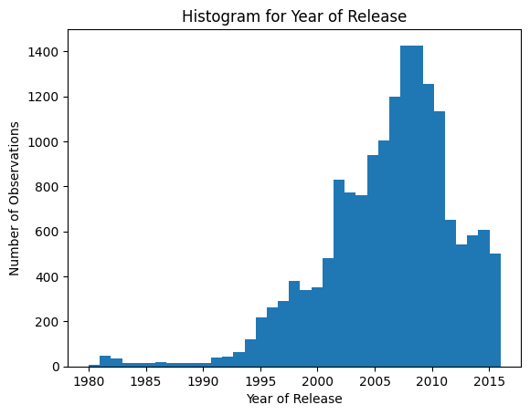

```python
# Look at how many games were released in different years

display(df_games['year_of_release'].value_counts().sort_index())

plt.hist(df_games['year_of_release'].dropna(), bins=37)
plt.xlabel('Year of Release')
plt.ylabel('Number of Observations')
plt.title('Histogram for Year of Release')
plt.show()
```

The number of games gradually increased during the 1980s and early 1990s, swelling appreciably in 1994, 2002, and 2005 before peaking in 2008, gradually declining, dropping substantially in 2012, and leveling off after that.

```
platform
GB      2.606735
NES     2.561735
GEN     1.061034
SNES    0.836987
PS4     0.801378
X360    0.769746
2600    0.729173
PS3     0.705973
Wii     0.687508
N64     0.685517
XOne    0.645020
PS      0.610576
PS2     0.581106
WiiU    0.559116
3DS     0.498077
GBA     0.386679
DS      0.374765
GC      0.357788
XB      0.312791
SCD     0.310000
DC      0.306731
PC      0.266448
PSP     0.243218
WS      0.236667
SAT     0.194162
PSV     0.125744
NG      0.120000
TG16    0.080000
GG      0.040000
3DO     0.033333
PCFX    0.030000
Name: total_sales, dtype: float64
```

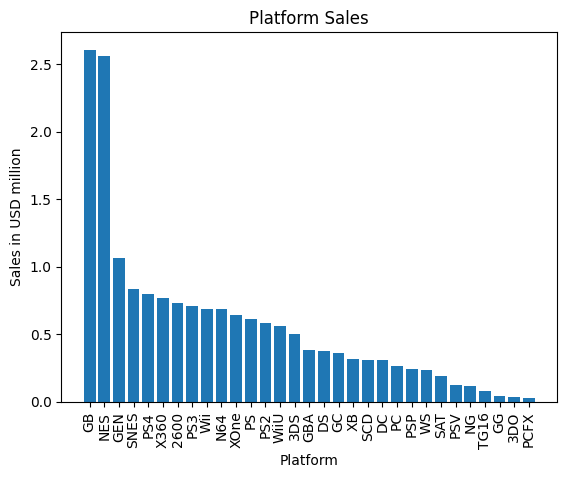

```python
# Look at how sales varied from platform to platform

platform_sales = df_games.groupby('platform')['total_sales'].mean().sort_values(ascending=False)
display(platform_sales)

plt.bar(platform_sales.index, platform_sales.values)
plt.xlabel('Platform')
plt.ylabel('Sales in USD million')
plt.title('Platform Sales')
plt.xticks(rotation=90)
plt.show()
```

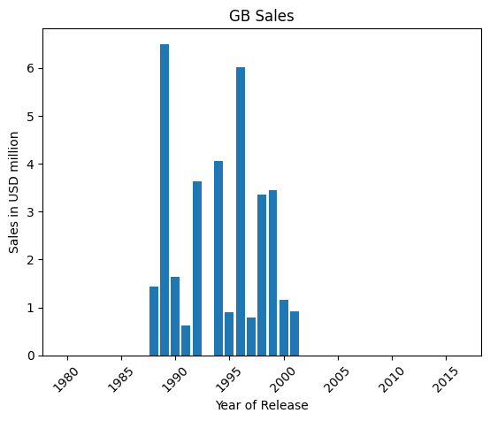

```
Number of years with sales > 0 = 13
```

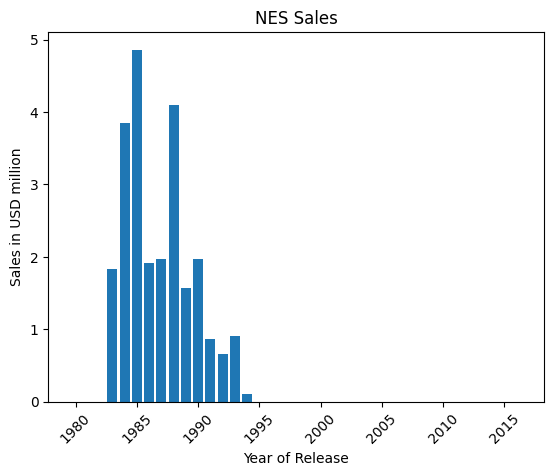

```
Number of years with sales > 0 = 12
```

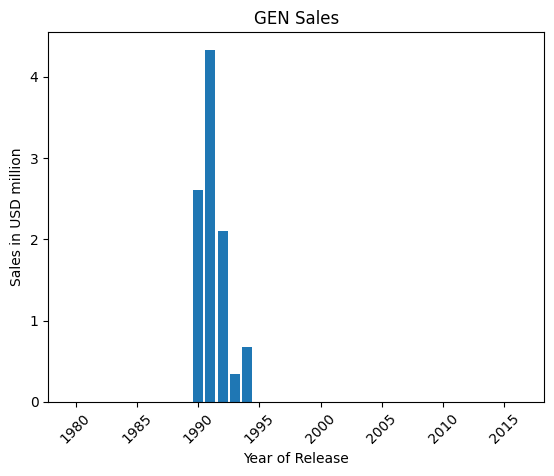

```
Number of years with sales > 0 = 5
```

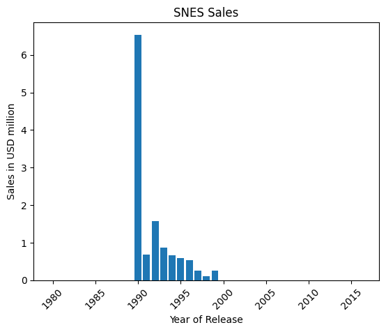

```
Number of years with sales > 0 = 10
```

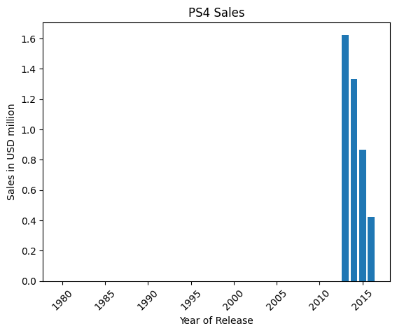

```
Number of years with sales > 0 = 4
```

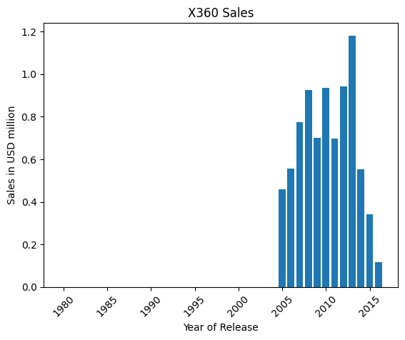

```
Number of years with sales > 0 = 12
```

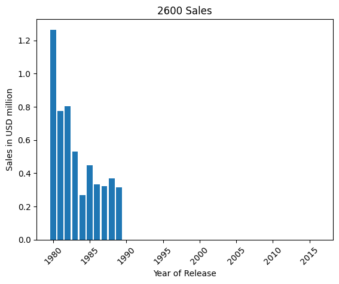

```
Number of years with sales > 0 = 10
```

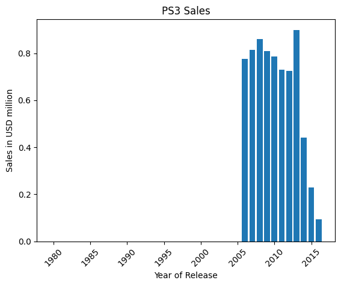

```
Number of years with sales > 0 = 11

Average sales lifetime for these platforms = 9.625 years
```

```python
# Look at total sales per year for the best selling platforms

top_platforms = ['GB', 'NES', 'GEN', 'SNES', 'PS4', 'X360', '2600', 'PS3']
lifetimes = []

for platform in top_platforms:
    platform_yearly_sales = df_games[df_games['platform'] == platform].groupby('year_of_release')['total_sales'].mean().reindex(range(1980, 2017), fill_value=0)
    lifetimes.append((platform_yearly_sales > 0).sum())

    plt.bar(platform_yearly_sales.index, platform_yearly_sales.values)
    plt.xlabel('Year of Release')
    plt.ylabel('Sales in USD million')
    plt.title(f'{platform} Sales')
    plt.xticks(rotation=45)
    plt.show()
    print(f'Number of years with sales > 0 = {lifetimes[-1]}')
    print()

print(f'Average sales lifetime for these platforms = {sum(lifetimes) / len(lifetimes)} years')
```

It takes very nearly a decade (9.6 years) for the best selling platforms to stop selling on average, though it ranges from 4 to 13 years. In trying to estimate sales in 2017, I will include data since 2013 to avoid tracking obsolete trends.

```python
# Create a new working dataframe without data < 2013

df_games_recent = df_games[df_games['year_of_release'] >= 2013]

display(df_games_recent.info())
```

```
<class 'pandas.core.frame.DataFrame'>
Int64Index: 2233 entries, 16 to 16714
Data columns (total 12 columns):
 #   Column           Non-Null Count  Dtype
---  ------           --------------  -----
 0   name             2233 non-null   object
 1   platform         2233 non-null   object
 2   year_of_release  2233 non-null   Int64
 3   genre            2233 non-null   object
 4   na_sales         2233 non-null   float64
 5   eu_sales         2233 non-null   float64
 6   jp_sales         2233 non-null   float64
 7   other_sales      2233 non-null   float64
 8   critic_score     991 non-null    Int64
 9   user_score       1192 non-null   float64
 10  rating           2233 non-null   object
 11  total_sales      2233 non-null   float64
dtypes: Int64(2), float64(6), object(4)
memory usage: 231.2+ KB
```

```
None
```

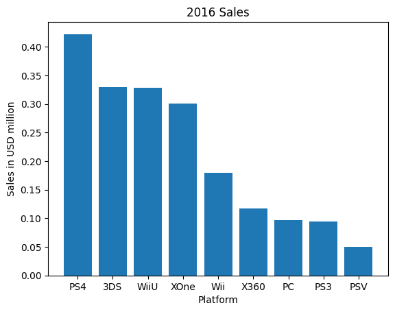

```python
# Look at which platforms are leading in sales in 2016

sales_2016 = df_games_recent[df_games_recent['year_of_release'] == 2016].groupby('platform')['total_sales'].mean().sort_values(ascending=False)

plt.bar(sales_2016.index, sales_2016)
plt.xlabel('Platform')
plt.ylabel('Sales in USD million')
plt.title(f'2016 Sales')
plt.show()
```

```
Average Total Sales Per Platform Per Recent Year of Release:
```

| platform | 2013 | 2014 | 2015 | 2016 |
| --- | --- | --- | --- | --- |
| PS4 | 1.624375 | 1.333333 | 0.867883 | 0.422256 |
| 3DS | 0.621648 | 0.547000 | 0.323023 | 0.329130 |
| WiiU | 0.515476 | 0.710645 | 0.583929 | 0.328571 |
| XOne | 0.997895 | 0.886393 | 0.751750 | 0.300575 |
| Wii | 0.715833 | 0.625000 | 0.285000 | 0.180000 |
| X360 | 1.181067 | 0.551429 | 0.341714 | 0.116923 |
| PC | 0.325789 | 0.282553 | 0.170400 | 0.097222 |
| PS3 | 0.898810 | 0.442222 | 0.230411 | 0.094737 |
| PSV | 0.168095 | 0.119000 | 0.056818 | 0.050000 |

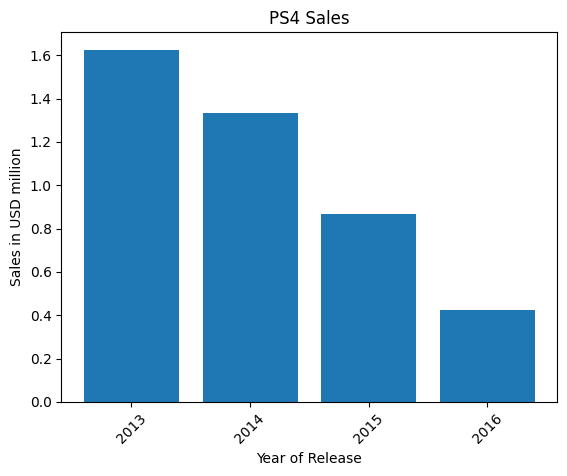

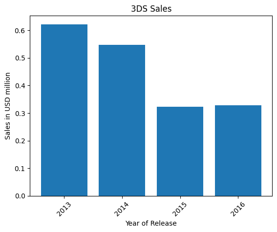

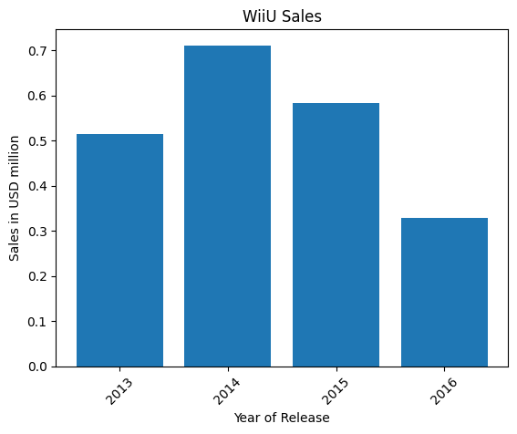

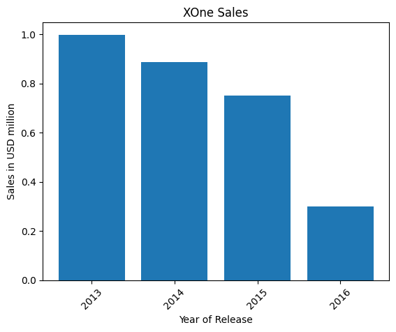

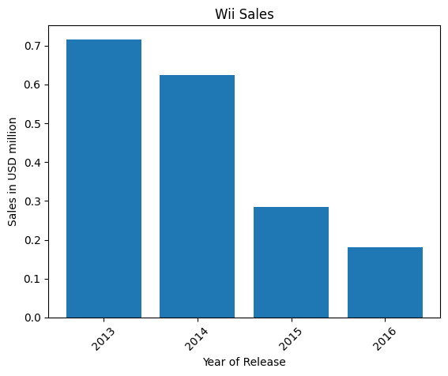

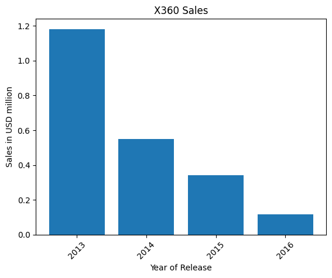

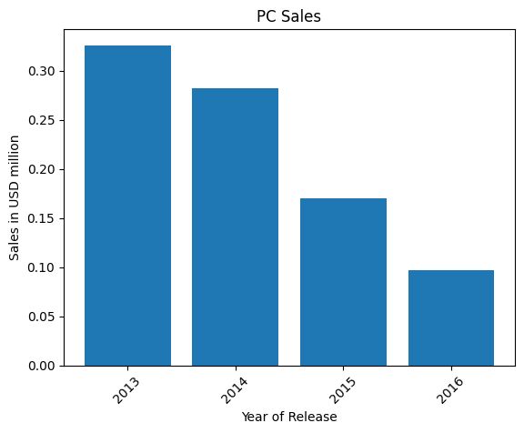

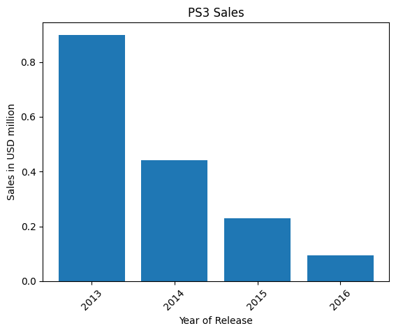

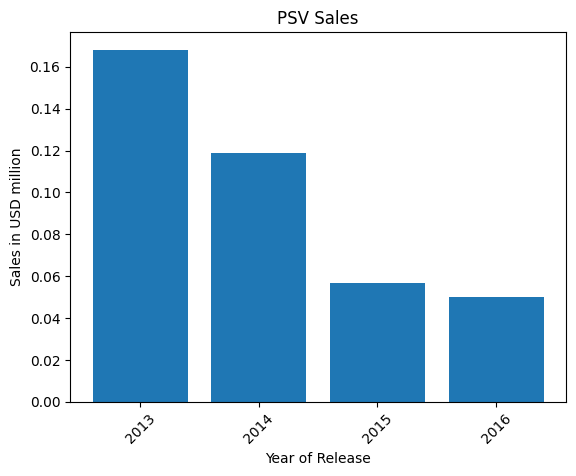

```python
# Explore recent platform sales trajectories

sales_2015 = df_games_recent[df_games_recent['year_of_release'] == 2015].groupby('platform')['total_sales'].mean()
sales_2014 = df_games_recent[df_games_recent['year_of_release'] == 2014].groupby('platform')['total_sales'].mean()
sales_2013 = df_games_recent[df_games_recent['year_of_release'] == 2013].groupby('platform')['total_sales'].mean()

recent_sales = pd.concat([sales_2013, sales_2014, sales_2015, sales_2016], axis=1)
recent_sales.columns = ['2013', '2014', '2015', '2016']
recent_sales = recent_sales.dropna(subset=['2016']).fillna(0)
recent_sales = recent_sales.sort_values(by='2016', ascending=False)

print('Average Total Sales Per Platform Per Recent Year of Release:')
display(recent_sales)
print()

for platform in recent_sales.T.columns:
    plt.bar(['2013', '2014', '2015', '2016'], recent_sales.T[platform])
    plt.xlabel('Year of Release')
    plt.ylabel('Sales in USD million')
    plt.title(f'{platform} Sales')
    plt.xticks(rotation=45)
    plt.show()
    print()
```

Every platform is declining in sales but whereas PS4, 3DS, WiiU, and XOne are still selling fairly well in 2016, Wii, X360, PC, PS3, and PSV are winding down.

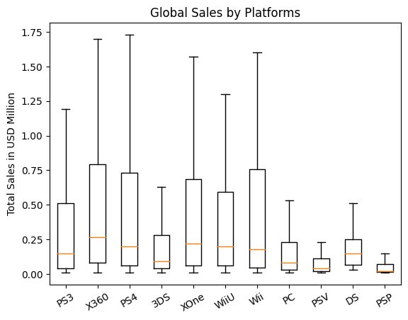

```python
# Build a series of box plots for the global sales of all games, broken down by platform

platforms = df_games_recent['platform'].unique()
platforms_total_sales = [df_games_recent[df_games_recent['platform'] == x]['total_sales'] for x in platforms]

plt.boxplot(platforms_total_sales, showfliers = False)
plt.xticks([x+1 for x in range(11)], platforms, rotation=30)
plt.ylabel('Total Sales in USD Million')
plt.title('Global Sales by Platforms')
plt.show()
```

```
platform
PS4     314.14
PS3     181.43
XOne    159.32
3DS     143.25
X360    136.80
WiiU     64.63
PC       39.43
PSV      32.99
Wii      13.66
PSP       3.50
DS        1.54
Name: total_sales, dtype: float64
```

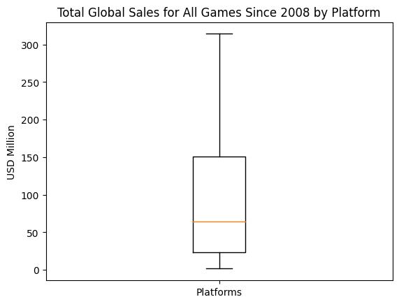

```python
# Build a single box plot for the global sales of all games, broken down by platform

display(df_games_recent.groupby('platform')['total_sales'].sum().sort_values(ascending=False))

plt.boxplot(df_games_recent.groupby('platform')['total_sales'].sum())
plt.xticks([1], ['Platforms'])
plt.ylabel('USD Million')
plt.title('Total Global Sales for All Games Since 2008 by Platform')
plt.show()
```

```python
# Test the difference in total sales among all platforms

platforms_total_sales = [df_games_recent[df_games_recent['platform'] == x]['total_sales'] for x in platforms]

print("One-Way ANOVA comparing total sales for each platform:")
print(f"F-statistic: {st.f_oneway(*platforms_total_sales)[0]:.2f}")
print(f"p-value: {st.f_oneway(*platforms_total_sales)[1]:.4f}")
```

```
One-Way ANOVA comparing total sales for each platform:
F-statistic: 9.65
p-value: 0.0000
```

```
platform
PS4     0.801378
X360    0.735484
XOne    0.645020
Wii     0.593913
WiiU    0.562000
PS3     0.525884
3DS     0.472772
PC      0.208624
DS      0.192500
PSV     0.092151
PSP     0.052239
Name: total_sales, dtype: float64
```

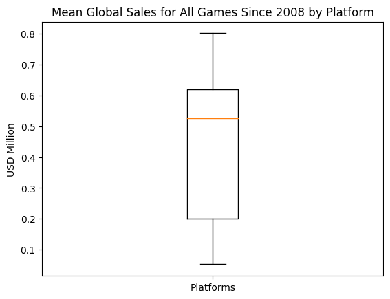

```python
# Build a box plot for the average global sales of all games, broken down by platform

display(df_games_recent.groupby('platform')['total_sales'].mean().sort_values(ascending=False))

plt.boxplot(df_games_recent.groupby('platform')['total_sales'].mean())
plt.xticks([1], ['Platforms'])
plt.ylabel('USD Million')
plt.title('Mean Global Sales for All Games Since 2008 by Platform')
plt.show()
```

The differences among platforms in global sales is significant (F = 9.65, p < 0.05), which means at least two platforms have significantly different means. PS4, PS3, XOne, 3DS, and X360 sold the most in total with noticeable drops after PS4 and X360. PS4, X360, and XOne sold the most on average followed by a steady decline. Given those numbers, PS4 and XOne appear to be the strongest sellers overall with their predecessors (PS3 and X360) not far behind.

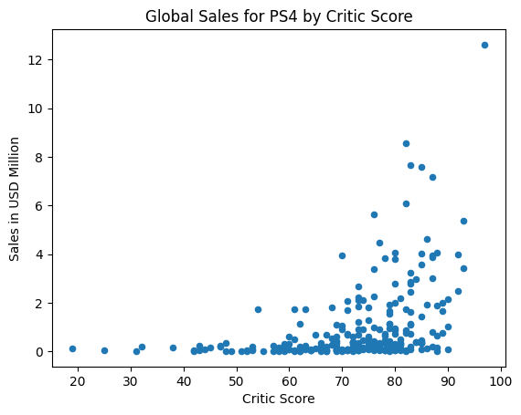

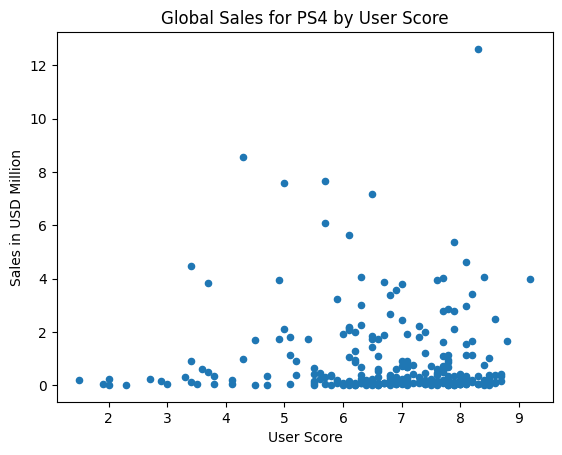

```python
# Build a scatter plot between reviews and sales for PS4

PS4_games = df_games_recent[df_games_recent['platform'] == 'PS4']

PS4_games.plot(x='critic_score', y='total_sales', kind='scatter', xlabel='Critic Score', ylabel='Sales in USD Million', title='Global Sales for PS4 by Critic Score')
PS4_games.plot(x='user_score', y='total_sales', kind='scatter', xlabel='User Score', ylabel='Sales in USD Million', title='Global Sales for PS4 by User Score')
```

```python
# Calculate the correlation between reviews and sales for PS4

for col in ['critic_score', 'user_score']:
    df_dropped = PS4_games[['platform','total_sales', col]].dropna()
    r, p = st.pearsonr(df_dropped['total_sales'], df_dropped[col])
    print(f'Correlation between total_sales and {col} for PS4')
    print(f'Correlation coefficient for PS4: {r:.2f}, P-value: {p:.4f}')
    print()
```

```
Correlation between total_sales and critic_score for PS4
Correlation coefficient for PS4: 0.41, P-value: 0.0000

Correlation between total_sales and user_score for PS4
Correlation coefficient for PS4: -0.03, P-value: 0.6101
```

For PS4 games, total sales is significantly correlated with critic score (r = 0.41, p < 0.05) but not user score (r = -0.03, p = 0.61). The scatterplot makes it clear that games with higher critic scores also have higher total sales, but we must resist attributing causality. Critics might prefer well-selling games, consumers might buy well-reviewed games, or both critic scores and sales might reflect a third variable such as game quality or marketing.

```python
# Create a function to compare the sales of the same games on other platforms

def reviews_by_sales_for_platform(df, platform):
    platform_games = df[df['platform'] == platform]
    platform_games.plot(x='critic_score', y='total_sales', kind='scatter', xlabel='Critic Score', ylabel='Sales in USD Million', title=f'Global Sales for {platform} by Critic Score')
    platform_games.plot(x='user_score', y='total_sales', kind='scatter', xlabel='User Score', ylabel='Sales in USD Million', title=f'Global Sales for {platform}  by User Score')

    for col in ['critic_score', 'user_score']:
        df_dropped = platform_games[['platform','total_sales', col]].dropna()
        r, p = st.pearsonr(df_dropped['total_sales'], df_dropped[col])
        print(f'Correlation between total_sales and {col} for {platform}')
        print(f'Correlation coefficient: {r:.2f}, P-value: {p:.4f}')
        print()
```

```
Correlation between total_sales and critic_score for PS3
Correlation coefficient: 0.33, P-value: 0.0002

Correlation between total_sales and user_score for PS3
Correlation coefficient: 0.00, P-value: 0.9741
```

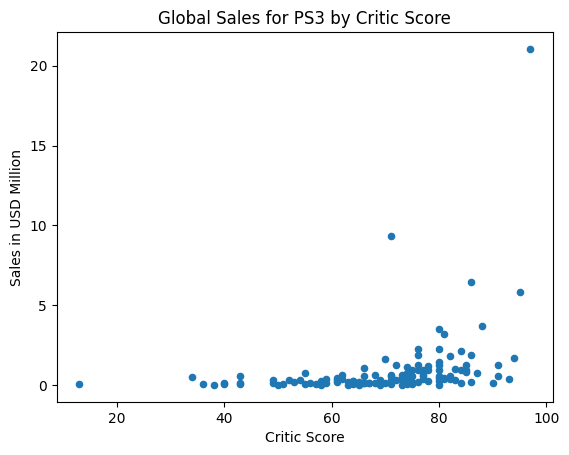

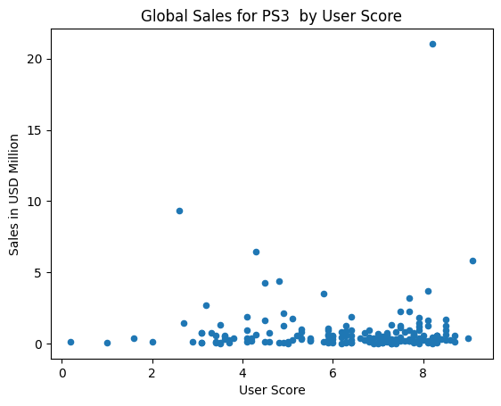

```python
# Compare the sales of the same games on other platforms (PS3)

reviews_by_sales_for_platform(df_games_recent, 'PS3')
```

```
Correlation between total_sales and critic_score for X360
Correlation coefficient: 0.35, P-value: 0.0013

Correlation between total_sales and user_score for X360
Correlation coefficient: -0.01, P-value: 0.8893
```

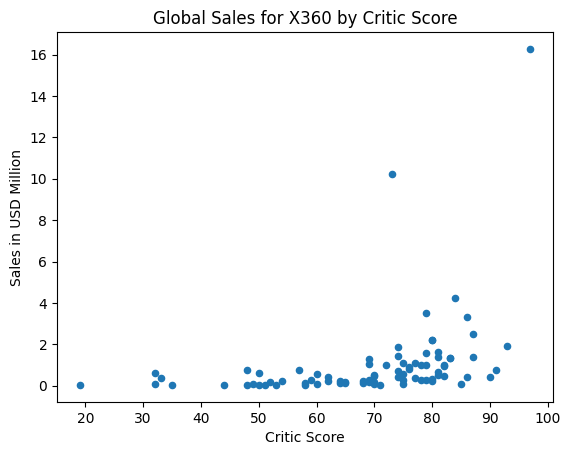

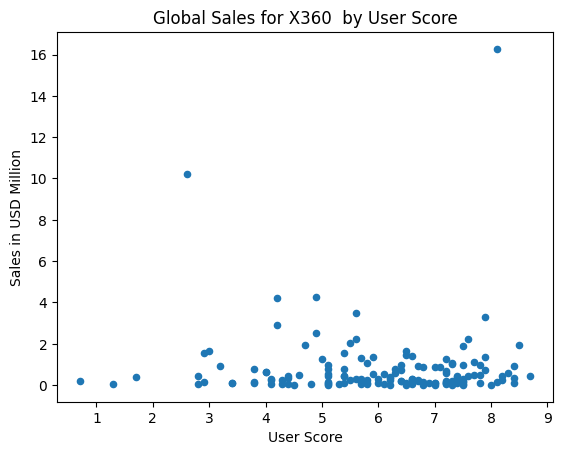

```python
# Compare the sales of the same games on other platforms (X360)

reviews_by_sales_for_platform(df_games_recent, 'X360')
```

```
Correlation between total_sales and critic_score for XOne
Correlation coefficient: 0.42, P-value: 0.0000

Correlation between total_sales and user_score for XOne
Correlation coefficient: -0.07, P-value: 0.3552
```

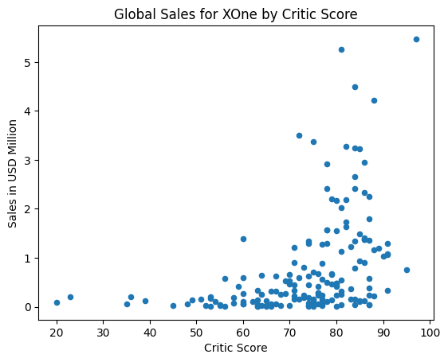

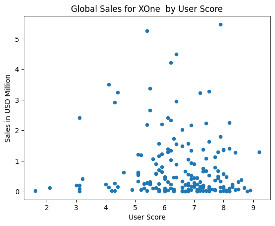

```python
# Compare the sales of the same games on other platforms (XOne)

reviews_by_sales_for_platform(df_games_recent, 'XOne')
```

```
Correlation between total_sales and critic_score for 3DS
Correlation coefficient: 0.36, P-value: 0.0022

Correlation between total_sales and user_score for 3DS
Correlation coefficient: 0.24, P-value: 0.0309
```

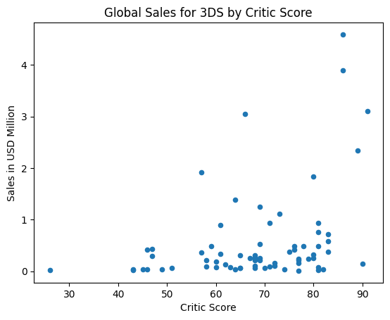

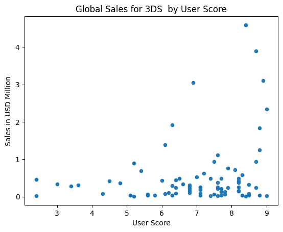

```python
# Compare the sales of the same games on other platforms (3DS)

reviews_by_sales_for_platform(df_games_recent, '3DS')
```

Having looked at four more platforms (PS3, X360, XOne, and 3DS), my conclusions about the relationship between reviews and sales for PS4 holds up pretty well. Critic score is moderately and significantly correlated with total sales for all platforms (Pearson's r ranging from 0.33 to 0.42; p < 0.05). The correlation between user score and total sales is noticeably weaker in every case (Pearson's r ranging from -.07 to 0.24) and only statistically significant (p < 0.05) for 3DS. Although user score is positively correlated with total sales sometimes, critic score is always a better predictor.

```
genre
Action          766
Role-Playing    292
Adventure       245
Sports          214
Shooter         187
Misc            155
Racing           85
Fighting         80
Platform         74
Simulation       62
Strategy         56
Puzzle           17
Name: total_sales, dtype: int64
```

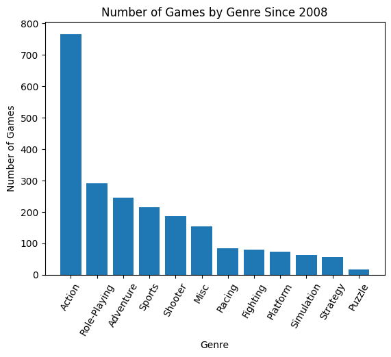

```python
# Take a look at the general distribution of games by genre

genre_counts = df_games_recent.groupby('genre')['total_sales'].count().sort_values(ascending=False)

display(genre_counts)

plt.bar(genre_counts.index, genre_counts.values)
plt.xlabel('Genre')
plt.ylabel('Number of Games')
plt.title('Number of Games by Genre Since 2008')
plt.xticks(rotation=60)
plt.show()
```

```
genre
Action          321.87
Shooter         232.98
Sports          150.65
Role-Playing    145.89
Misc             62.82
Platform         42.63
Racing           39.89
Fighting         35.31
Adventure        23.64
Simulation       21.76
Strategy         10.08
Puzzle            3.17
Name: total_sales, dtype: float64
```

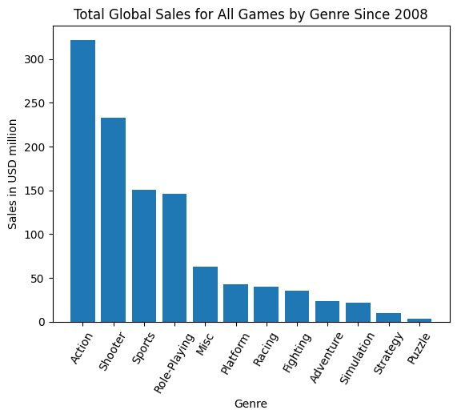

```python
# Examine total sales by genre

genre_total_sales = df_games_recent.groupby('genre')['total_sales'].sum().sort_values(ascending=False)

display(genre_total_sales)

plt.bar(genre_total_sales.index, genre_total_sales.values)
plt.xlabel('Genre')
plt.ylabel('Sales in USD million')
plt.title('Total Global Sales for All Games by Genre Since 2008')
plt.xticks(rotation=60)
plt.show()
```

```
genre
Shooter         1.245882
Sports          0.703972
Platform        0.576081
Role-Playing    0.499623
Racing          0.469294
Fighting        0.441375
Action          0.420196
Misc            0.405290
Simulation      0.350968
Puzzle          0.186471
Strategy        0.180000
Adventure       0.096490
Name: total_sales, dtype: float64
```

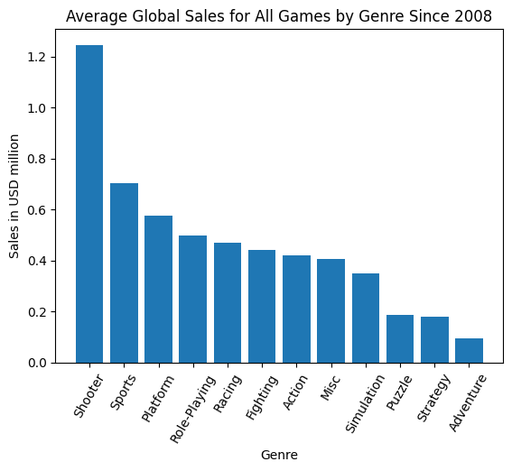

```python
# Examine average sales by genre

genre_avg_sales = df_games_recent.groupby('genre')['total_sales'].mean().sort_values(ascending=False)

display(genre_avg_sales)

plt.bar(genre_avg_sales.index, genre_avg_sales.values)
plt.xlabel('Genre')
plt.ylabel('Sales in USD million')
plt.title('Average Global Sales for All Games by Genre Since 2008')
plt.xticks(rotation=60)
plt.show()
```

Looking at total global sales, Action games sell the most followed after a drop by Shooter, then Sports and Role-Playing after another drop. Looking at average global sales, Shooter games are the most lucrative followed after a drop by Sports, Platform, and then a gradual decline. Action games are by far the most common in the dataset, which explains their dominant total sales. Sports games are solid sellers, third in total sales and second in average sales. Despite having the third highest average sales, Platform games have weak total sales because they are uncommon in the dataset.

```python
# Check average sales/revenue per game per genre

for genre in df_games_recent['genre'].unique():
    genre_avg_sales = df_games_recent[df_games_recent['genre'] == genre]
    genre_avg_sales = genre_avg_sales.groupby(['name'])['total_sales'].mean().sort_values(ascending=False).head(5)
    genre_avg_sales = genre_avg_sales.to_frame().reset_index()
    genre_avg_sales.index += 1
    genre_avg_sales.columns = ['name', 'avg sales']

    print(f'Top Five Games for Average Global Sales in the {genre} Genre')
    display(genre_avg_sales)
    print()
```

```
Top Five Games for Average Global Sales in the Action Genre
```

|  | name | avg sales |
| --- | --- | --- |
| 1 | Grand Theft Auto V | 11.316 |
| 2 | The Last of Us | 5.290 |
| 3 | Uncharted: The Nathan Drake Collection | 4.620 |
| 4 | Luigi's Mansion: Dark Moon | 4.590 |
| 5 | Monster Hunter X | 3.320 |

```
Top Five Games for Average Global Sales in the Shooter Genre
```

|  | name | avg sales |
| --- | --- | --- |
| 1 | Uncharted 4: A Thief's End | 5.390 |
| 2 | Call of Duty: Black Ops 3 | 5.134 |
| 3 | Call of Duty: Ghosts | 4.565 |
| 4 | Halo 5: Guardians | 4.490 |
| 5 | Splatoon | 4.440 |

```
Top Five Games for Average Global Sales in the Role-Playing Genre
```

|  | name | avg sales |
| --- | --- | --- |
| 1 | Pokemon X/Pokemon Y | 14.600000 |
| 2 | Pokemon Omega Ruby/Pokemon Alpha Sapphire | 11.680000 |
| 3 | Pokemon Sun/Moon | 7.140000 |
| 4 | Fallout 4 | 4.223333 |
| 5 | Monster Hunter 4 Ultimate | 3.890000 |

```
Top Five Games for Average Global Sales in the Misc Genre
```

|  | name | avg sales |
| --- | --- | --- |
| 1 | Minecraft | 4.026667 |
| 2 | Mario Party: Island Tour | 1.920000 |
| 3 | Wii Party U | 1.750000 |
| 4 | Mario Party 10 | 1.580000 |
| 5 | Just Dance 2014 | 1.066667 |

```
Top Five Games for Average Global Sales in the Sports Genre
```

|  | name | avg sales |
| --- | --- | --- |
| 1 | FIFA 16 | 3.260000 |
| 2 | FIFA 17 | 2.296000 |
| 3 | FIFA 15 | 2.171250 |
| 4 | Madden NFL 16 | 1.850000 |
| 5 | FIFA 14 | 1.828889 |

```
Top Five Games for Average Global Sales in the Fighting Genre
```

|  | name | avg sales |
| --- | --- | --- |
| 1 | Super Smash Bros. for Wii U and 3DS | 6.210000 |
| 2 | Mortal Kombat X | 1.403333 |
| 3 | Pokken Tournament | 1.010000 |
| 4 | Injustice: Gods Among Us | 0.760000 |
| 5 | Naruto Shippuden: Ultimate Ninja Storm 3 | 0.725000 |

```
Top Five Games for Average Global Sales in the Racing Genre
```

|  | name | avg sales |
| --- | --- | --- |
| 1 | Mario Kart 8 | 7.09 |
| 2 | Gran Turismo 6 | 3.23 |
| 3 | Forza Motorsport 5 | 2.20 |
| 4 | DriveClub | 2.07 |
| 5 | Forza Motorsport 6 | 1.80 |

```
Top Five Games for Average Global Sales in the Simulation Genre
```

|  | name | avg sales |
| --- | --- | --- |
| 1 | Tomodachi Life | 5.220 |
| 2 | The Sims 4 | 3.050 |
| 3 | Animal Crossing: Happy Home Designer | 3.050 |
| 4 | SimCity (2013) | 1.420 |
| 5 | Farming Simulator 2015 | 0.496 |

```
Top Five Games for Average Global Sales in the Platform Genre
```

|  | name | avg sales |
| --- | --- | --- |
| 1 | Super Mario 3D World | 4.32 |
| 2 | Super Mario Maker | 3.21 |
| 3 | New Super Luigi U | 2.23 |
| 4 | Donkey Kong Country Returns | 1.90 |
| 5 | Kirby: Triple Deluxe | 1.83 |

```
Top Five Games for Average Global Sales in the Strategy Genre
```

|  | name | avg sales |
| --- | --- | --- |
| 1 | StarCraft II: Heart of the Swarm | 1.67 |
| 2 | Pikmin 3 | 1.12 |
| 3 | Total War: Rome II | 0.72 |
| 4 | StarCraft II: Legacy of the Void | 0.52 |
| 5 | Sid Meier's Civilization: Beyond Earth | 0.36 |

```
Top Five Games for Average Global Sales in the Adventure Genre
```

|  | name | avg sales |
| --- | --- | --- |
| 1 | Until Dawn | 1.66 |
| 2 | Beyond: Two Souls | 1.64 |
| 3 | Disney Magical World | 0.93 |
| 4 | Rise of the Tomb Raider | 0.69 |
| 5 | Tearaway | 0.62 |

```
Top Five Games for Average Global Sales in the Puzzle Genre
```

|  | name | avg sales |
| --- | --- | --- |
| 1 | Captain Toad: Treasure Tracker | 1.19 |
| 2 | Professor Layton and the Azran Legacy | 0.76 |
| 3 | Puzzle & Dragons Z + Super Mario Bros. Edition | 0.48 |
| 4 | Picross 3D 2 | 0.11 |
| 5 | Scribblenauts Unmasked: A DC Comics Adventure | 0.10 |

# Create Profiles

```python
# Create a function to examine total regional sales

def examine_regional_sales(df, region, column):
    df_grouped = df.groupby(column)[f'{region}_sales'].sum().sort_values(ascending=False)

    display(df_grouped)

    plt.bar(df_grouped.index, df_grouped.values)
    plt.xlabel(column)
    plt.ylabel('Sales in USD million')
    plt.title(f'Total {region}_sales by {column} Since 2008')
    plt.xticks(rotation=60)
    plt.show()
```

```
platform
PS4     108.74
XOne     93.12
X360     81.66
PS3      63.50
3DS      38.20
WiiU     29.21
PC       11.11
Wii       6.56
PSV       5.04
DS        0.57
PSP       0.00
Name: na_sales, dtype: float64
```

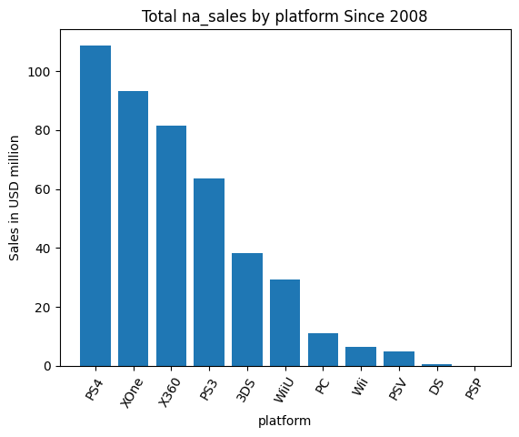

```
platform
PS4     141.09
PS3      67.81
XOne     51.59
X360     42.52
3DS      30.96
PC       25.36
WiiU     19.85
PSV       6.10
Wii       5.93
DS        0.85
PSP       0.17
Name: eu_sales, dtype: float64
```

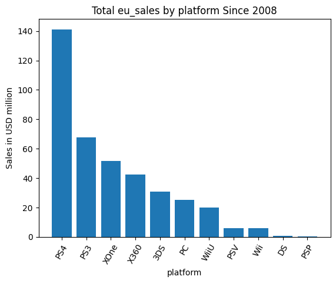

```
platform
3DS     67.81
PS3     23.35
PSV     18.59
PS4     15.96
WiiU    10.88
PSP      3.29
X360     0.51
XOne     0.34
Wii      0.05
DS       0.00
PC       0.00
Name: jp_sales, dtype: float64
```

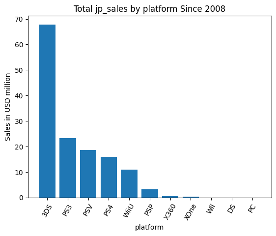

```python
# Create a platform profile for each region

examine_regional_sales(df_games_recent, 'na', 'platform')
examine_regional_sales(df_games_recent, 'eu', 'platform')
examine_regional_sales(df_games_recent, 'jp', 'platform')
```

```python
# Compare market shares for platforms in each region

platforms = ['PS4', 'XOne', 'X360', 'PS3', '3DS', 'PSV', 'WiiU']
regions = ['na_sales', 'eu_sales', 'jp_sales']

platform_dict = {}
for platform in platforms:
    region_list = []
    for region in regions:
        market_share = 100*df_games_recent[df_games_recent['platform'] == platform][region].sum()/df_games_recent[region].sum()
        region_list.append(market_share)
    platform_dict[platform] = region_list
platform_market_share = pd.DataFrame(platform_dict).T
platform_market_share.columns = regions

print('Regional Market Share (% of Regional Sales) by Platform:')
display(platform_market_share)
```

```
Regional Market Share (% of Regional Sales) by Platform:
```

|  | na_sales | eu_sales | jp_sales |
| --- | --- | --- | --- |
| PS4 | 24.842933 | 35.971241 | 11.336838 |
| XOne | 21.274360 | 13.152997 | 0.241512 |
| X360 | 18.656188 | 10.840578 | 0.362267 |
| PS3 | 14.507322 | 17.288326 | 16.586163 |
| 3DS | 8.727239 | 7.893328 | 48.167353 |
| PSV | 1.151447 | 1.555210 | 13.205001 |
| WiiU | 6.673368 | 5.060806 | 7.728371 |

Top five platforms for each region:

- North America: PS4, XOne, X360, PS3, 3DS
- Europe: PS4, PS3, XOne, X360, 3DS
- Japan: 3DS, PS3, PSV, PS4, WiiU

The platform profiles for North America (PS4, XOne, X360, PS3, 3DS) and Europe (PS4, PS3, XOne, X360, 3DS) are broadly similar with PS4 dominating both markets. The remaining order only differs in PS3 jumping from fourth place in North America to second place in Europe. There are some notable differences such as XOne and X360 having almost twice the market share in North America while PS4 has noticeably higher market share in Europe. Japan has a distinct platform profile (3DS, PS3, PSV, PS4, WiiU) with nearly 6 times the other regions' market share for 3DS and 10 times that for PSV but less than 1/2 their market shares for PS4, 1/30 that for X360, and 1/50 that for XOne.

Each market has a clear preference for platform: North America prefers Microsoft consoles, Europe prefers Sony consoles, and Japan prefers Nintendo (and other) mobile platforms. Although Sony also sells in Japan, Microsoft is almost completely absent there.

```
genre
Action          126.05
Shooter         109.74
Sports           65.27
Role-Playing     46.40
Misc             27.49
Platform         18.14
Fighting         15.55
Racing           12.96
Adventure         7.14
Simulation        4.86
Strategy          3.28
Puzzle            0.83
Name: na_sales, dtype: float64
```

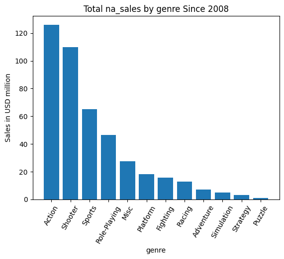

```
genre
Action          118.13
Shooter          87.86
Sports           60.52
Role-Playing     36.97
Racing           20.19
Misc             20.04
Platform         15.58
Simulation       10.92
Fighting          8.55
Adventure         8.25
Strategy          4.22
Puzzle            1.00
Name: eu_sales, dtype: float64
```

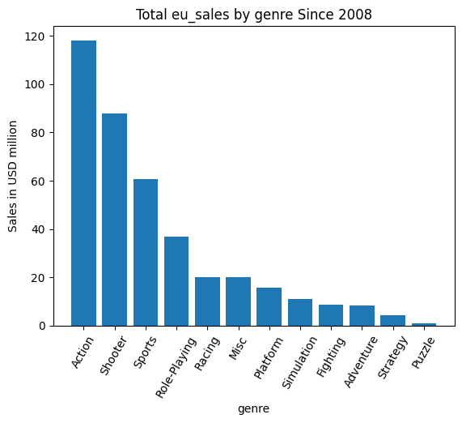

```
genre
Role-Playing    51.04
Action          40.49
Misc             9.20
Fighting         7.65
Shooter          6.61
Adventure        5.82
Sports           5.41
Platform         4.79
Simulation       4.52
Racing           2.30
Strategy         1.77
Puzzle           1.18
Name: jp_sales, dtype: float64
```

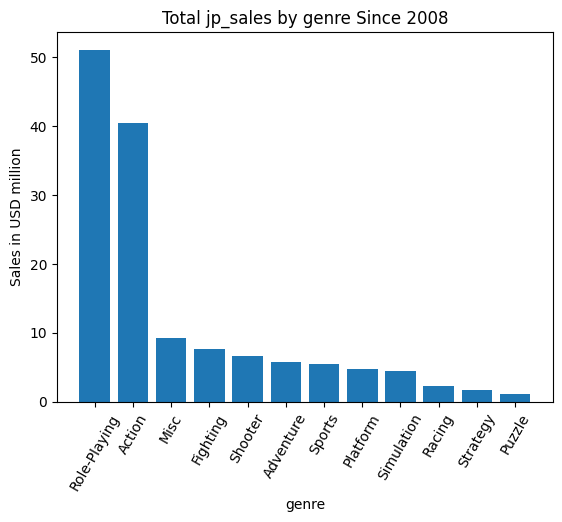

```python
# Create a genre profile for each region

examine_regional_sales(df_games_recent, 'na', 'genre')
examine_regional_sales(df_games_recent, 'eu', 'genre')
examine_regional_sales(df_games_recent, 'jp', 'genre')
```

```python
# Compare market shares for genres in each region

genres = ['Action', 'Shooter', 'Sports', 'Role-Playing', 'Misc', 'Racing', 'Fighting']
regions = ['na_sales', 'eu_sales', 'jp_sales']

genre_dict = {}
for genre in genres:
    region_list = []
    for region in regions:
        market_share = 100*df_games_recent[df_games_recent['genre'] == genre][region].sum()/df_games_recent[region].sum()
        region_list.append(market_share)
    genre_dict[genre] = region_list
genre_market_share = pd.DataFrame(genre_dict).T
genre_market_share.columns = regions

print('Regional Market Share (% of Regional Sales) by Genre:')
display(genre_market_share)
```

```
Regional Market Share (% of Regional Sales) by Genre:
```

|  | na_sales | eu_sales | jp_sales |
| --- | --- | --- | --- |
| Action | 28.797606 | 30.117533 | 28.761188 |
| Shooter | 25.071394 | 22.400122 | 4.695269 |
| Sports | 14.911700 | 15.429722 | 3.842875 |
| Role-Playing | 10.600626 | 9.425592 | 36.255150 |
| Misc | 6.280414 | 5.109247 | 6.535019 |
| Racing | 2.960864 | 5.147490 | 1.633755 |
| Fighting | 3.552580 | 2.179843 | 5.434011 |

Top five genres for each region:

- North America: Action, Shooter, Sports, Role-Playing, Misc
- Europe: Action, Shooter, Sports, Role-Playing, Racing
- Japan: Role-Playing, Action, Misc, Fighting, Shooter

The platform profiles for North America (Action, Shooter, Sports, Role-Playing, Misc) and Europe (Action, Shooter, Sports, Role-Playing, Racing) are identical except for the last spot. Action and Shooter genres dominate both markets and market shares are comparable for all relevant genres. Japan has a different profile (Role-Playing, Action, Misc, Fighting, Shooter) with about 3.5 times the other regions' market share for Role-Playing games but only 1/4 their market shares for Sports and 1/5 that for Shooter. Market share for Action is consistent across all three markets.

Japanese consumers like Role-Playing games more and Shooter and Sports games much less than North American and European consumers but all markets agree on Action games.

```
rating
M          165.21
unknown     89.42
E           79.05
E10+        54.24
T           49.79
Name: na_sales, dtype: float64
```

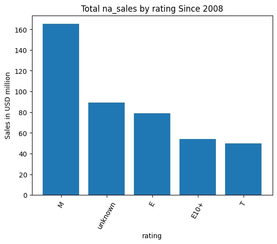

```
rating
M          145.32
E           83.36
unknown     78.91
E10+        42.69
T           41.95
Name: eu_sales, dtype: float64
```

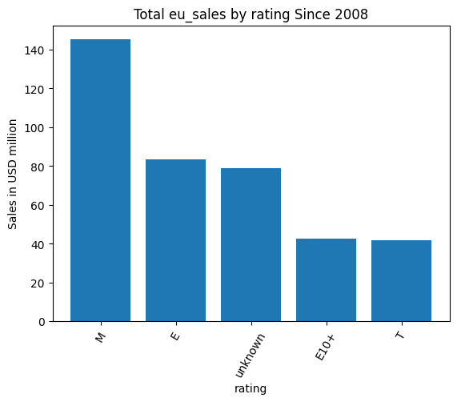

```
rating
unknown    85.05
T          20.59
E          15.14
M          14.11
E10+        5.89
Name: jp_sales, dtype: float64
```

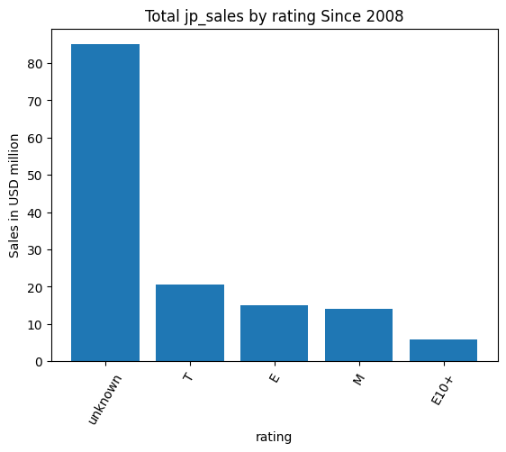

```python
# Create an ESRB rating profile for each region

examine_regional_sales(df_games_recent, 'na', 'rating')
examine_regional_sales(df_games_recent, 'eu', 'rating')
examine_regional_sales(df_games_recent, 'jp', 'rating')
```

```python
# Test the difference in regional sales among ESRB ratings

ratings = ['E', 'M', 'T', 'E10+']
ratings_na_sales = [df_games_recent[df_games_recent['rating'] == x]['na_sales'] for x in ratings]
ratings_eu_sales = [df_games_recent[df_games_recent['rating'] == x]['eu_sales'] for x in ratings]
ratings_jp_sales = [df_games_recent[df_games_recent['rating'] == x]['jp_sales'] for x in ratings]

print("One-Way ANOVA comparing North American sales for each rating:")
print(f"F-statistic: {st.f_oneway(*ratings_na_sales)[0]:.2f}")
print(f"p-value: {st.f_oneway(*ratings_na_sales)[1]:.4f}")
print()
print("One-Way ANOVA comparing European sales for each rating:")
print(f"F-statistic: {st.f_oneway(*ratings_eu_sales)[0]:.2f}")
print(f"p-value: {st.f_oneway(*ratings_eu_sales)[1]:.4f}")
print()
print("One-Way ANOVA comparing Japanese sales for each rating:")
print(f"F-statistic: {st.f_oneway(*ratings_jp_sales)[0]:.2f}")
print(f"p-value: {st.f_oneway(*ratings_jp_sales)[1]:.4f}")
```

```
One-Way ANOVA comparing North American sales for each rating:
F-statistic: 16.46
p-value: 0.0000

One-Way ANOVA comparing European sales for each rating:
F-statistic: 14.13
p-value: 0.0000

One-Way ANOVA comparing Japanese sales for each rating:
F-statistic: 4.04
p-value: 0.0072
```

Top five ratings for each region:

- North America: M, unknown, E, E10+, T
- Europe: M, E, unknown, E10+, T
- Japan: unknown, T, E, M, E10+

The rating profiles for North American (M, unknown, E, E10+, T) and European (M, E, unknown, E10+, T) markets are very similar with M dominating followed after a drop by unknown and E (in different orders) and then E10+ and T after another drop. The Japanese rating profile (unknown, T, E, M, E10+) is quite different with unknown selling more than 4 times as much as T followed by steady decline for E, M, and E10+. ANOVAs reveal that ESRB ratings affect sales (i.e., at least one rating sells significantly better than another) in all three markets (p < 0.05).

North America and Europe clearly prefer M (Mature) and Japan prefers unknown almost to the exclusion of all others. It looks like Japan uses a different rating system (CERO instead of ESRB), which explains why their best selling games have unknown ratings.

# Test Hypotheses

```python
# Test equality of variances for average user ratings of the Xbox One and PC platforms

XOne_user_scores = df_games_recent[df_games_recent['platform'] == 'XOne']['user_score'].dropna()
PC_user_scores = df_games_recent[df_games_recent['platform'] == 'PC']['user_score'].dropna()

print('Descriptives for PC user_scores:')
display(PC_user_scores.describe())
print()
print('Descriptives for XOne user_scores:')
display(XOne_user_scores.describe())
print()
print("Levene's test comparing the variances of user_score for XOne and PC platforms:")
print(f"t-statistic: {st.levene(XOne_user_scores, PC_user_scores, center='median')[0]:.2f}")
print(f"p-value: {st.levene(XOne_user_scores, PC_user_scores, center='median')[1]:.4f}")
```

```
Descriptives for PC user_scores:
```

```
count    155.000000
mean       6.269677
std        1.742381
min        1.400000
25%        5.300000
50%        6.800000
75%        7.600000
max        9.300000
Name: user_score, dtype: float64
```

```
Descriptives for XOne user_scores:
```

```
count    182.000000
mean       6.521429
std        1.380941
min        1.600000
25%        5.800000
50%        6.800000
75%        7.500000
max        9.200000
Name: user_score, dtype: float64
```

```
Levene's test comparing the variances of user_score for XOne and PC platforms:
t-statistic: 8.45
p-value: 0.0039
```

```python
# Test the hypothesis that the average user ratings of the Xbox One and PC platforms are the same

print("Independent t-test comparing user_score for XOne and PC platforms:")
print(f"t-statistic: {st.ttest_ind(XOne_user_scores, PC_user_scores, equal_var=False)[0]:.2f}")
print(f"p-value: {st.ttest_ind(XOne_user_scores, PC_user_scores, equal_var=False)[1]:.4f}")
```

```
Independent t-test comparing user_score for XOne and PC platforms:
t-statistic: 1.45
p-value: 0.1476
```

Null Hypothesis: XOne and PC platforms have equal user scores  
Alternative Hypothesis: XOne and PC platforms have different user scores  
Statistical Test: Independent t-test with alpha = 0.05 and equal variances not assumed  
Conclusion: We cannot reject the null hypothesis (t = 1.45, p = 0.15)

```python
# Test equality of variances for average user ratings of the Action and Sports genres

Action_user_scores = df_games_recent[df_games_recent['genre'] == 'Action']['user_score'].dropna()
Sports_user_scores = df_games_recent[df_games_recent['genre'] == 'Sports']['user_score'].dropna()

print('Descriptives for Action user_scores:')
display(Action_user_scores.describe())
print()
print('Descriptives for Sports user_scores:')
display(Sports_user_scores.describe())
print()
print("Levene's test comparing the variances of user_score for Action and Sports genres:")
print(f"t-statistic: {st.levene(Action_user_scores, Sports_user_scores, center='median')[0]:.2f}")
print(f"p-value: {st.levene(Action_user_scores, Sports_user_scores, center='median')[1]:.4f}")
```

```
Descriptives for Action user_scores:
```

```
count    389.000000
mean       6.837532
std        1.330173
min        2.000000
25%        6.300000
50%        7.100000
75%        7.800000
max        9.100000
Name: user_score, dtype: float64
```

```
Descriptives for Sports user_scores:
```

```
count    160.000000
mean       5.238125
std        1.783427
min        0.200000
25%        4.100000
50%        5.500000
75%        6.500000
max        8.800000
Name: user_score, dtype: float64
```

```
Levene's test comparing the variances of user_score for Action and Sports genres:
t-statistic: 26.21
p-value: 0.0000
```

```python
# Test the hypothesis that the average user ratings for the Action and Sports genres are different

print("Independent t-test comparing user_score for Action and Sports genres:")
print(f"t-statistic: {st.ttest_ind(Action_user_scores, Sports_user_scores, equal_var=False)[0]:.2f}")
print(f"p-value: {st.ttest_ind(Action_user_scores, Sports_user_scores, equal_var=False)[1]:.4f}")
```

```
Independent t-test comparing user_score for Action and Sports genres:
t-statistic: 10.23
p-value: 0.0000
```

Null Hypothesis: Action and Sports genres have equal user scores  
Alternative Hypothesis: Action and Sports genres have different user scores  
Statistical Test: Independent t-test with alpha = 0.05 and equal variances not assumed  
Conclusion: We can reject the null hypothesis (t = 10.23, p < 0.05)

I conclude that user ratings are significantly higher for the Action genre than for the Sports genre, but XOne and PC platforms are not significanlty different.

For both of these tests, I formulated the null and alternative hypotheses in the same way they are always formulated: the null hypothesis posits no difference between conditions and the alternative hypothesis posits a difference between conditions. I also chose the standard significance level used across the social sciences: alpha = 0.05. I did not assume equal variances for either t-test because of significant (p < 0.05) Levene's tests for both sets of data.

# General Discussion

I began by preparing the data, making a few formatting adjustments, and investigating missing values. I found a large segment of data (6,621 rows) simultaneously missing values in the critic_score, user_score, and rating columns. Besides selling well only in Japan, nothing obviously distinguishes those rows from the rest. My best guess is that the critic_score, user_score, and rating columns came from a smaller dataset separate from the rest of the columns, maybe one that excluded certain Japanese games. There are also 2,424 rows with "tbd" for user_score. They tend to be poor-selling games predominantly made by Nintendo, marketed for kids, and low in violence. Without a good explanation for them, I treated them like other missing data.

Several columns have relatively small numbers of additional missing values (2 for name, 2 for genre, 80 for user_score, 145 for rating, 269 for year_of_release, and 1,957 for critic_score) that show no obvious patterns. I tried to use all the data available but no more, neither deleting nor arbitrarily filling missing values. I replaced NaN values in the rating column with "unknown" to track those in later analyses. The lifetime of a top-selling platform is less than a decade (9.6 years) and the best sellers in the full dataset (PS3 and X360) are quite old. In estimating 2017 sales, I tried to exclude obsolete trends by dropping data from before 2013.

The best-selling platforms in recent years were PS4 and XOne. Global sales was declining for every platform in 2016, but PS4, 3DS, WiiU, and XOne had strong sales while Wii, X360, PC, PS3, and PSV were rapidly dwindling. Reviews are significantly correlated with global sales for top-selling games, with critic score consistently a better predictor than user score. Shooter games make the most money on average, Action games sell the most overall because there are so many, Platform games are lucrative but rare, and Sports games are a good middle ground with solid margins and volume. Simulation, Strategy, and Puzzle games, on the other hand, are all poor sellers.

I created profiles for the North American, European, and Japanese markets. Whereas North America prefers Microsoft consoles and Europe prefers Sony consoles, Japan prefers portable Nintendo platforms more and Microsoft less than the rest. Every region enjoys Action games, but North America and Europe also like Shooter games while Japan prefers Role-Playing games. Games rated M (Mature) are the best sellers in North America and Europe but unknown ratings dominate Japan where a different rating system prevails.

Statistical tests reveal that user scores are significantly higher for Action than Sports genres but not significantly different for XOne and PC platforms.

The purpose of this project is to determine what would make a game sell well in 2017 according to indicators in the dataset and I came to a few potentially useful conclusions. Although the heyday of massive PS3 and X360 sales has passed, the current generation (PS4, 3DS, WiiU, and XOne) is still going strong. Advertising should focus on those newer platforms and the Shooter, Sports, and Platform genres while minimizing the Simulation, Strategy, and Puzzle genres. They should also prioritize games with high critic scores, maybe even including the scores in ads in case the effect is causal. Advertising should emphasize Microsoft, Shooter, and rated-M games in in North America; Sony, Shooter, and rated-M games in Europe; and portable Nintendo and Role-Playing games in Japan.